# Moral Anger or Disgust First? Exploring the Primacy Effect in Victim and Perpetrator Foci

Eva L. Vives, Astrid Thébault Guiochon, Bastien Trémolière, Agnès Falco, Hakim Djeriouat

Script: Astrid Thébault Guiochon & Eva L. Vives

# I – Loading

## 1. Librairies

```r
library(aod)
library(broom.mixed)
library(car)
library(data.table)
library(dplyr)
library(effects)
library(emmeans)
library(fitdistrplus)
library(ggeffects)
library(ggplot2)
library(ggpubr)
library(ggthemes)
library(gridExtra)
library(gtsummary)
library(labelled)
library(lme4)
library(lmerTest)
library(lmtest)
library(magrittr)
library(MuMIn)
library(nortest)
library(performance)
library(plyr)
library(plotly)
library(readr)
library(readxl)
library(sjPlot)
library(tidyr)
source('./ggplot_theme_Publication-2.R')
```

## 2. Working directory

⚠️ Adapt to your computer

## 3. Dataset

💡 Opens an explorer window (or use file path)

# II – Preview

## 1. Demographics

### a) Study 1

```r
summary_data = data[,] %>%
  select(prolific_ID, age, political_orientation, genre) %>%
  group_by(prolific_ID) %>%
  summarise(
    age = first(age),
    political_orientation = first(political_orientation),
    genre = first(genre),
    .groups = 'drop')

summary(summary_data)
```

```
##  prolific_ID             age        political_orientation    genre
##  Length:173         Min.   :18.00   1:20                  Length:173
##  Class :character   1st Qu.:25.00   2:49                  Class :character
##  Mode  :character   Median :33.00   3:22                  Mode  :character
##                     Mean   :37.24   4:37
##                     3rd Qu.:48.00   5:20
##                     Max.   :73.00   6:16
##                     NA's   :2       7: 9
```

```r
count(summary_data$genre)
```

```
##         x freq
## 1   A man   93
## 2 A woman   80
```

### b) Study 2

```r
summary_data2 = data2[,] %>%
  select(prolific_ID, age, political_orientation, genre) %>%
  group_by(prolific_ID) %>%
  summarise(
    age = first(age),
    political_orientation = first(political_orientation),
    genre = first(genre),
    .groups = 'drop')

summary_data2
```

```
## # A tibble: 139 × 4
##    prolific_ID                age political_orientation genre
##    <chr>                    <int> <fct>                 <chr>
##  1 55895b93fdf99b6bd06017c4    56 7                     A man
##  2 5671927473f58b000d664293    32 1                     A woman
##  3 56721761980a3c0011277389    51 5                     A woman
##  4 575865ba7b74a80006de2689    31 1                     A man
##  5 57bf14513c449a000189c89a    70 1                     A man
##  6 588fc465a7e5300001199329    39 7                     A man
##  7 58adfc6e7cf56d0001f931a2    26 2                     A man
##  8 58e558cc728bea0001bbda24    66 5                     A woman
##  9 5a61207cc0d8360001078f07    49 7                     A woman
## 10 5ab6cbbbf69e940001d8e446    58 1                     A woman
## # ℹ 129 more rows
```

```r
count(summary_data2$genre)
```

```
##         x freq
## 1   A man   66
## 2 A woman   73
```

## 2. Distribution of reaction time

### a) Study 1

```r
fit_norm = fitdist(as.numeric(na.exclude(data$rt_net)), distr = "norm")
#shapiro.test(data$rt_net)
ad.test(data$rt_net) #Anderson Darling as shapiro test has a samplz size max
```

```
##
##  Anderson-Darling normality test
##
## data:  data$rt_net
## A = 650.88, p-value < 2.2e-16
```

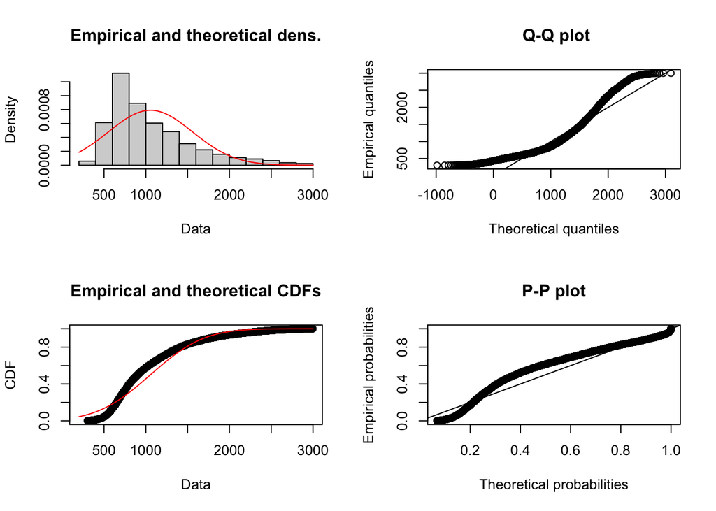

```r
fit_log = fitdist(as.numeric(log((na.exclude(data$rt_net)))), distr = "norm")

plot(fit_norm)
```

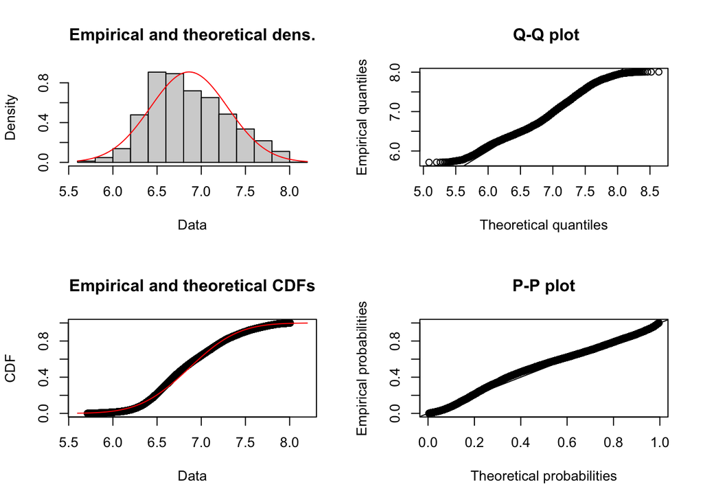

```r
plot(fit_log)
```

### b) Study 2

```r
fit_norm2 = fitdist(as.numeric(na.exclude(data2$rt_net)), distr = "norm")
#shapiro.test(data2$rt_net)
ad.test(data2$rt_net) #Anderson Darling as shapiro test has a samplz size max
```

```
##
##  Anderson-Darling normality test
##
## data:  data2$rt_net
## A = 192.83, p-value < 2.2e-16
```

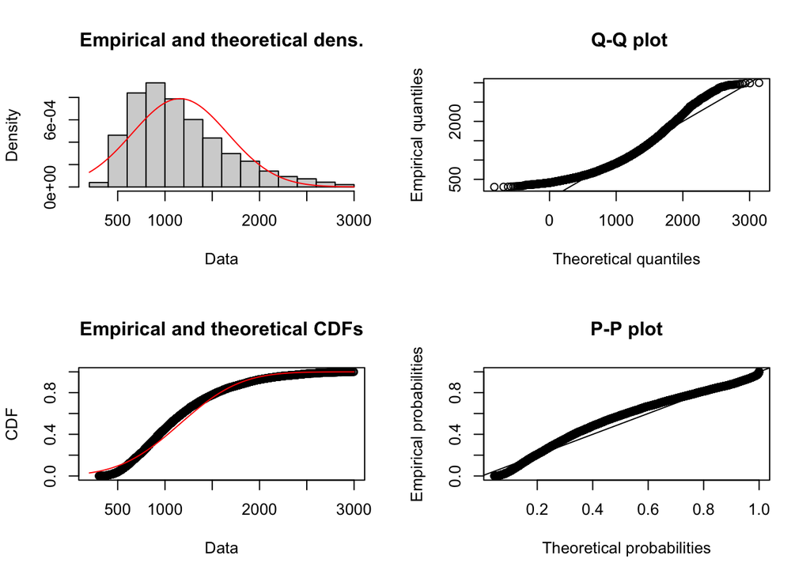

```r
fit_log2 = fitdist(as.numeric(log((na.exclude(data2$rt_net)))), distr = "norm")

plot(fit_norm2)
```

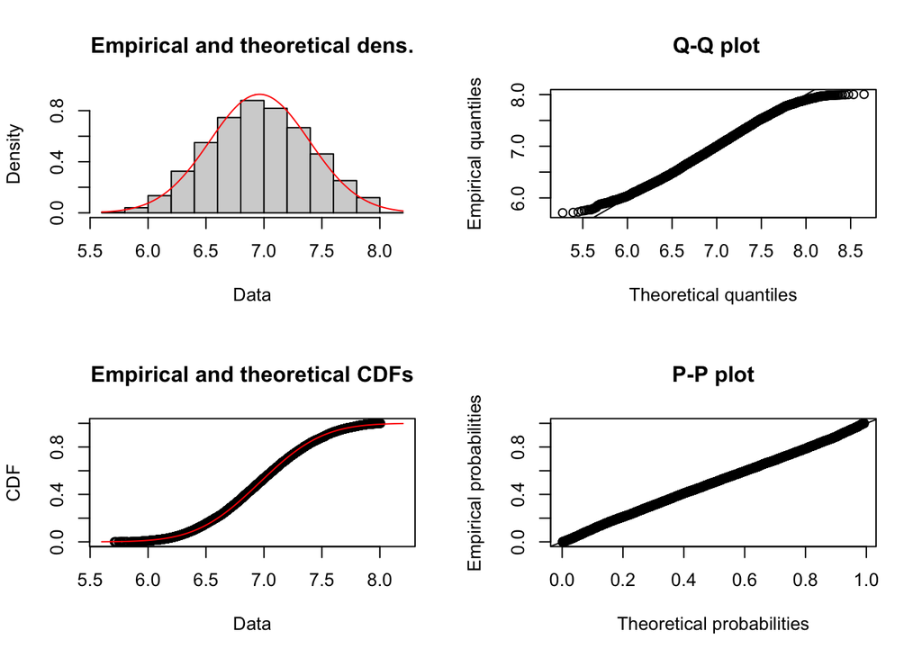

```r
plot(fit_log2)
```

# III – Models

## 1. Study 1

### a) Reaction Time

#### Full mixed-effect model

```r
full = lmer(log(rt_net) ~ condition * newemo + (1|number_ID) + (1|item),
           na.action = na.omit,
           data = data)
```

Summary

```r
tbl_regression(full,
               label = list(condition ~ "Condition",
                            newemo ~ "Emotion")) %>%
  modify_column_unhide(column = std.error) %>%
  modify_column_unhide(column = statistic) %>%
  modify_header(label = "**Variable**") %>%
  bold_p() %>%
  modify_fmt_fun(statistic ~ style_sigfig) %>%
  add_significance_stars(hide_ci = FALSE,
                         hide_p = FALSE,
                         pattern = "{p.value}{stars}") %>%
  add_glance_source_note(label = list(sigma ~ "\U03C3"),
                         include = c(AIC, sigma))
```

| **Variable** | **Beta** | **SE**<sup>1</sup> | **Statistic** | **95% CI**<sup>1</sup> | **p-value**<sup>2</sup> |
| --- | --- | --- | --- | --- | --- |
| Condition |  |  |  |  |  |
| Perpetrator | — | — | — | — |  |
| Victim | -0.02 | 0.046 | -0.34 | -0.11, 0.07 | 0.7 |
| Emotion |  |  |  |  |  |
| Anger | — | — | — | — |  |
| Disgust | 0.02 | 0.012 | 1.9 | 0.00, 0.05 | 0.064 |
| Joy | -0.01 | 0.012 | -0.53 | -0.03, 0.02 | 0.6 |
| Neutral | 0.10 | 0.012 | 8.3 | 0.08, 0.12 | <0.001*** |
| Fear | 0.07 | 0.012 | 6.0 | 0.05, 0.10 | <0.001*** |
| Sadness | 0.05 | 0.012 | 4.3 | 0.03, 0.07 | <0.001*** |
| Condition * Emotion |  |  |  |  |  |
| Victim * Disgust | 0.03 | 0.017 | 1.7 | -0.01, 0.06 | 0.10 |
| Victim * Joy | -0.04 | 0.017 | -2.2 | -0.07, 0.00 | 0.027* |
| Victim * Neutral | -0.01 | 0.017 | -0.74 | -0.05, 0.02 | 0.5 |
| Victim * Fear | 0.00 | 0.017 | 0.18 | -0.03, 0.04 | 0.9 |
| Victim * Sadness | -0.04 | 0.017 | -2.4 | -0.07, -0.01 | 0.016* |

AIC = 12,899; σ = 0.333  
<sup>1</sup> SE = Standard Error, CI = Confidence Interval  
<sup>2</sup> *p<0.05; **p<0.01; ***p<0.001

Anova & conditional and marginal coefficient of determination

```r
Anova(full, type = 3, ddf = "Satterthwaite")
```

```
## Analysis of Deviance Table (Type III Wald chisquare tests)
##
## Response: log(rt_net)
##                       Chisq Df Pr(>Chisq)
## (Intercept)      43707.5729  1  < 2.2e-16 ***
## condition            0.1146  1  0.7349855
## newemo             120.9978  5  < 2.2e-16 ***
## condition:newemo    23.8197  5  0.0002351 ***
## ---
## Signif. codes:  0 '***' 0.001 '**' 0.01 '*' 0.05 '.' 0.1 ' ' 1
```

```r
round(r.squaredGLMM(full, method = "marginal"), 4)
```

```
##         R2m    R2c
## [1,] 0.0098 0.4393
```

- Main effect of *Emotion*
  $$\chi^2(5)
  = 120.998, p < .001$$
- Interaction between *Condition* and *Emotion*
  $$\chi^2(5) = 23.82, p < .001$$

Variance explained by the model:
$$R^2_m =
0.98\% \text{ (fixed)}$$
$$R^2_c =
43.93\% \text{ (fixed + random)}$$

#### Pairwise comparisons & estimated marginal means

```r
emmeans(full, pairwise ~ newemo, lmer.df = "asymp", type = "response", adjust = "bonferroni")
```

```
## $emmeans
##  newemo  response   SE  df asymp.LCL asymp.UCL
##  Anger        937 21.6 Inf       896       980
##  Disgust      971 22.4 Inf       929      1016
##  Joy          914 21.0 Inf       874       956
##  Neutral     1029 23.7 Inf       984      1077
##  Fear        1009 23.2 Inf       964      1055
##  Sadness      966 22.2 Inf       924      1011
##
## Results are averaged over the levels of: condition
## Degrees-of-freedom method: asymptotic
## Confidence level used: 0.95
## Intervals are back-transformed from the log scale
##
## $contrasts
##  contrast          ratio      SE  df null z.ratio p.value
##  Anger / Disgust   0.965 0.00809 Inf    1  -4.303  0.0003
##  Anger / Joy       1.025 0.00855 Inf    1   2.964  0.0455
##  Anger / Neutral   0.910 0.00770 Inf    1 -11.100  <.0001
##  Anger / Fear      0.929 0.00781 Inf    1  -8.786  <.0001
##  Anger / Sadness   0.970 0.00810 Inf    1  -3.694  0.0033
##  Disgust / Joy     1.063 0.00889 Inf    1   7.266  <.0001
##  Disgust / Neutral 0.944 0.00801 Inf    1  -6.809  <.0001
##  Disgust / Fear    0.963 0.00812 Inf    1  -4.480  0.0001
##  Disgust / Sadness 1.005 0.00842 Inf    1   0.626  1.0000
##  Joy / Neutral     0.888 0.00749 Inf    1 -14.053  <.0001
##  Joy / Fear        0.906 0.00760 Inf    1 -11.750  <.0001
##  Joy / Sadness     0.946 0.00788 Inf    1  -6.668  <.0001
##  Neutral / Fear    1.020 0.00867 Inf    1   2.348  0.2830
##  Neutral / Sadness 1.065 0.00900 Inf    1   7.459  <.0001
##  Fear / Sadness    1.044 0.00877 Inf    1   5.123  <.0001
##
## Results are averaged over the levels of: condition
## Degrees-of-freedom method: asymptotic
## P value adjustment: bonferroni method for 15 tests
## Tests are performed on the log scale
```

```r
emmeans(full, pairwise ~ condition, lmer.df = "asymp", type = "response", adjust = "bonferroni")
```

```
## $emmeans
##  condition   response   SE  df asymp.LCL asymp.UCL
##  Perpetrator      983 31.3 Inf       923      1046
##  Victim           958 30.0 Inf       901      1019
##
## Results are averaged over the levels of: newemo
## Degrees-of-freedom method: asymptotic
## Confidence level used: 0.95
## Intervals are back-transformed from the log scale
##
## $contrasts
##  contrast             ratio     SE  df null z.ratio p.value
##  Perpetrator / Victim  1.03 0.0457 Inf    1   0.568  0.5700
##
## Results are averaged over the levels of: newemo
## Degrees-of-freedom method: asymptotic
## Tests are performed on the log scale
```

```r
emmeans(full, pairwise ~ newemo|condition, lmer.df = "asymp", type = "response", adjust = "bonferroni")
```

```
## $emmeans
## condition = Perpetrator:
##  newemo  response   SE  df asymp.LCL asymp.UCL
##  Anger        944 30.9 Inf       886      1007
##  Disgust      966 31.6 Inf       905      1030
##  Joy          938 30.7 Inf       880      1001
##  Neutral     1044 34.3 Inf       979      1113
##  Fear        1015 33.3 Inf       952      1083
##  Sadness      994 32.6 Inf       932      1060
##
## condition = Victim:
##  newemo  response   SE  df asymp.LCL asymp.UCL
##  Anger        930 29.9 Inf       873       990
##  Disgust      977 31.5 Inf       918      1041
##  Joy          891 28.7 Inf       836       949
##  Neutral     1015 32.7 Inf       953      1081
##  Fear        1003 32.3 Inf       941      1068
##  Sadness      940 30.2 Inf       882      1001
##
## Degrees-of-freedom method: asymptotic
## Confidence level used: 0.95
## Intervals are back-transformed from the log scale
##
## $contrasts
## condition = Perpetrator:
##  contrast          ratio     SE  df null z.ratio p.value
##  Anger / Disgust   0.978 0.0117 Inf    1  -1.852  0.9606
##  Anger / Joy       1.006 0.0120 Inf    1   0.528  1.0000
##  Anger / Neutral   0.905 0.0110 Inf    1  -8.255  <.0001
##  Anger / Fear      0.930 0.0111 Inf    1  -6.050  <.0001
##  Anger / Sadness   0.950 0.0114 Inf    1  -4.258  0.0003
##  Disgust / Joy     1.029 0.0123 Inf    1   2.382  0.2585
##  Disgust / Neutral 0.925 0.0112 Inf    1  -6.412  <.0001
##  Disgust / Fear    0.951 0.0114 Inf    1  -4.187  0.0004
##  Disgust / Sadness 0.972 0.0117 Inf    1  -2.401  0.2454
##  Joy / Neutral     0.899 0.0109 Inf    1  -8.791  <.0001
##  Joy / Fear        0.924 0.0110 Inf    1  -6.588  <.0001
##  Joy / Sadness     0.944 0.0113 Inf    1  -4.793  <.0001
##  Neutral / Fear    1.028 0.0125 Inf    1   2.286  0.3336
##  Neutral / Sadness 1.050 0.0127 Inf    1   4.045  0.0008
```

[output cut: 8 more lines]

```
##  Anger / Sadness   0.989 0.0115 Inf    1  -0.919  1.0000
##  Disgust / Joy     1.098 0.0128 Inf    1   7.953  <.0001
##  Disgust / Neutral 0.963 0.0114 Inf    1  -3.177  0.0223
##  Disgust / Fear    0.975 0.0116 Inf    1  -2.140  0.4856
##  Disgust / Sadness 1.040 0.0122 Inf    1   3.358  0.0118
##  Joy / Neutral     0.877 0.0103 Inf    1 -11.119  <.0001
##  Joy / Fear        0.888 0.0105 Inf    1 -10.050  <.0001
##  Joy / Sadness     0.948 0.0110 Inf    1  -4.635  0.0001
##  Neutral / Fear    1.012 0.0121 Inf    1   1.025  1.0000
##  Neutral / Sadness 1.080 0.0127 Inf    1   6.544  <.0001
##  Fear / Sadness    1.067 0.0126 Inf    1   5.489  <.0001
##
## Degrees-of-freedom method: asymptotic
## P value adjustment: bonferroni method for 15 tests
## Tests are performed on the log scale
```

#### Plot all interaction effects

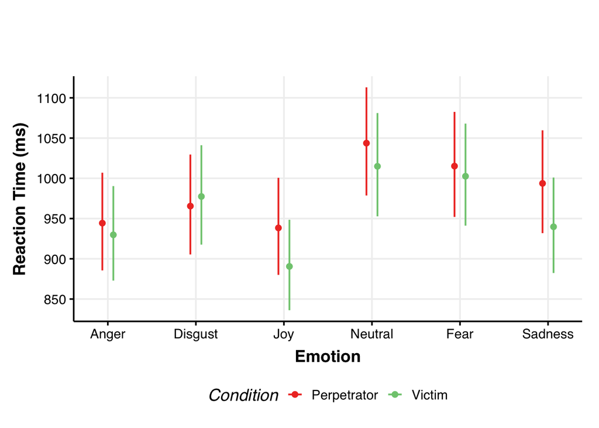

```r
plotfull = ggpredict(full, terms = c("newemo", "condition"), ci_level = 0.95) %>%
  plot() +
  labs(x = "Emotion", y = "Reaction Time (ms)", colour = "Condition", title = "", element_text(size = 14)) +
  scale_fill_Publication() +
  scale_colour_Publication() +
  theme_Publication() +
  scale_y_continuous(breaks = c(800, 850, 900, 950, 1000, 1050, 1100, 1150))

plotfull
```

### b) Emotional Hits

#### Full generalized mixed-effect model

```r
emo = glmer(score ~ newemo * condition + (1|number_ID) + (1|item),
          data = data,
          family = binomial,
          na.action = na.omit,
          control = glmerControl(optimizer = "bobyqa"))
```

Summary

```r
tbl_regression(emo,
               label = list(condition ~ "Condition",
                            newemo ~ "Emotion")) %>%
  modify_column_unhide(column = std.error) %>%
  modify_column_unhide(column = statistic) %>%
  modify_header(label = "**Variable**") %>%
  bold_p() %>%
  modify_fmt_fun(statistic ~ style_sigfig) %>%
  add_significance_stars(hide_ci = FALSE,
                         hide_p = FALSE,
                         pattern = "{p.value}{stars}") %>%
  add_glance_source_note(label = list(sigma ~ "\U03C3"),
                         include = c(AIC, sigma))
```

| **Variable** | **log(OR)**<sup>1</sup> | **SE**<sup>1</sup> | **Statistic** | **95% CI**<sup>1</sup> | **p-value**<sup>2</sup> |
| --- | --- | --- | --- | --- | --- |
| Emotion |  |  |  |  |  |
| Anger | — | — | — | — |  |
| Disgust | -0.22 | 0.109 | -2.0 | -0.44, -0.01 | 0.042* |
| Joy | 0.01 | 0.111 | 0.06 | -0.21, 0.22 | >0.9 |
| Neutral | -1.1 | 0.104 | -11 | -1.3, -0.93 | <0.001*** |
| Fear | -1.0 | 0.104 | -10 | -1.2, -0.83 | <0.001*** |
| Sadness | -0.94 | 0.104 | -9.0 | -1.1, -0.73 | <0.001*** |
| Condition |  |  |  |  |  |
| Perpetrator | — | — | — | — |  |
| Victim | 0.35 | 0.304 | 1.2 | -0.24, 0.95 | 0.2 |
| Emotion * Condition |  |  |  |  |  |
| Disgust * Victim | -0.61 | 0.163 | -3.7 | -0.93, -0.29 | <0.001*** |
| Joy * Victim | 0.47 | 0.185 | 2.5 | 0.11, 0.83 | 0.011* |
| Neutral * Victim | -0.35 | 0.156 | -2.3 | -0.66, -0.05 | 0.024* |
| Fear * Victim | -0.57 | 0.156 | -3.7 | -0.88, -0.27 | <0.001*** |
| Sadness * Victim | 0.90 | 0.170 | 5.3 | 0.57, 1.2 | <0.001*** |

AIC = 14,107; σ = 1.00  
<sup>1</sup> OR = Odds Ratio, SE = Standard Error, CI = Confidence Interval  
<sup>2</sup> *p<0.05; **p<0.01; ***p<0.001

Anova & conditional and marginal coefficient of determination

```r
Anova(emo, type = 3, ddf = "Satterthwaite")
```

```
## Analysis of Deviance Table (Type III Wald chisquare tests)
##
## Response: score
##                     Chisq Df Pr(>Chisq)
## (Intercept)      154.9353  1     <2e-16 ***
## newemo           264.8088  5     <2e-16 ***
## condition          1.3632  1      0.243
## newemo:condition 145.6447  5     <2e-16 ***
## ---
## Signif. codes:  0 '***' 0.001 '**' 0.01 '*' 0.05 '.' 0.1 ' ' 1
```

```r
round(r.squaredGLMM(emo, method = "marginal"), 4)
```

```
##                R2m    R2c
## theoretical 0.0654 0.5307
## delta       0.0440 0.3574
```

- Main effect of *Emotion*
  $$\chi^2(5)
  = 264.81, p < .001$$
- Interaction between *Condition* and *Emotion*
  $$\chi^2(5) = 145.645, p < .001$$

Variance explained by the model:
$$R^2_m =
4.40\% \text{ (fixed)}$$
$$R^2_c =
35.74\% \text{ (fixed + random)}$$

#### Pairwise comparisons (estimated marginal means and pairwise comparisons)

```r
emmeans(emo, pairwise ~ newemo, lmer.df = "asymp", type = "response", adjust = "bonferroni")
```

```
## $emmeans
##  newemo   prob      SE  df asymp.LCL asymp.UCL
##  Anger   0.950 0.00781 Inf     0.932     0.963
##  Disgust 0.918 0.01209 Inf     0.891     0.939
##  Joy     0.960 0.00638 Inf     0.946     0.971
##  Neutral 0.836 0.02164 Inf     0.789     0.874
##  Fear    0.835 0.02173 Inf     0.788     0.873
##  Sadness 0.921 0.01181 Inf     0.894     0.941
##
## Results are averaged over the levels of: condition
## Confidence level used: 0.95
## Intervals are back-transformed from the logit scale
##
## $contrasts
##  contrast          odds.ratio     SE  df null z.ratio p.value
##  Anger / Disgust        1.695 0.1386 Inf    1   6.450  <.0001
##  Anger / Joy            0.786 0.0728 Inf    1  -2.597  0.1412
##  Anger / Neutral        3.720 0.2903 Inf    1  16.834  <.0001
##  Anger / Fear           3.746 0.2919 Inf    1  16.944  <.0001
##  Anger / Sadness        1.629 0.1383 Inf    1   5.745  <.0001
##  Disgust / Joy          0.464 0.0405 Inf    1  -8.800  <.0001
##  Disgust / Neutral      2.195 0.1554 Inf    1  11.105  <.0001
##  Disgust / Fear         2.210 0.1562 Inf    1  11.224  <.0001
##  Disgust / Sadness      0.961 0.0757 Inf    1  -0.505  1.0000
##  Joy / Neutral          4.731 0.3967 Inf    1  18.533  <.0001
##  Joy / Fear             4.763 0.3990 Inf    1  18.636  <.0001
##  Joy / Sadness          2.071 0.1864 Inf    1   8.087  <.0001
##  Neutral / Fear         1.007 0.0658 Inf    1   0.105  1.0000
##  Neutral / Sadness      0.438 0.0326 Inf    1 -11.094  <.0001
##  Fear / Sadness         0.435 0.0323 Inf    1 -11.197  <.0001
##
## Results are averaged over the levels of: condition
## P value adjustment: bonferroni method for 15 tests
## Tests are performed on the log odds ratio scale
```

```r
emmeans(emo, pairwise ~ condition, lmer.df = "asymp", type = "response", adjust = "bonferroni")
```

```
## $emmeans
##  condition    prob     SE  df asymp.LCL asymp.UCL
##  Perpetrator 0.901 0.0186 Inf     0.858     0.932
##  Victim      0.927 0.0140 Inf     0.894     0.950
##
## Results are averaged over the levels of: newemo
## Confidence level used: 0.95
## Intervals are back-transformed from the logit scale
##
## $contrasts
##  contrast             odds.ratio    SE  df null z.ratio p.value
##  Perpetrator / Victim      0.721 0.202 Inf    1  -1.165  0.2439
##
## Results are averaged over the levels of: newemo
## Tests are performed on the log odds ratio scale
```

```r
emmeans(emo, pairwise ~ newemo|condition, lmer.df = "asymp", type = "response", adjust = "bonferroni")
```

```
## $emmeans
## condition = Perpetrator:
##  newemo   prob      SE  df asymp.LCL asymp.UCL
##  Anger   0.941 0.01238 Inf     0.911     0.961
##  Disgust 0.927 0.01492 Inf     0.892     0.951
##  Joy     0.941 0.01232 Inf     0.912     0.961
##  Neutral 0.836 0.02973 Inf     0.769     0.886
##  Fear    0.850 0.02774 Inf     0.787     0.896
##  Sadness 0.861 0.02595 Inf     0.802     0.905
##
## condition = Victim:
##  newemo   prob      SE  df asymp.LCL asymp.UCL
##  Anger   0.958 0.00912 Inf     0.936     0.972
##  Disgust 0.908 0.01812 Inf     0.866     0.938
##  Joy     0.973 0.00607 Inf     0.958     0.983
##  Neutral 0.836 0.02913 Inf     0.771     0.886
##  Fear    0.819 0.03138 Inf     0.750     0.873
##  Sadness 0.956 0.00941 Inf     0.934     0.971
##
## Confidence level used: 0.95
## Intervals are back-transformed from the logit scale
##
## $contrasts
## condition = Perpetrator:
##  contrast          odds.ratio     SE  df null z.ratio p.value
##  Anger / Disgust        1.249 0.1361 Inf    1   2.038  0.6233
##  Anger / Joy            0.994 0.1108 Inf    1  -0.056  1.0000
##  Anger / Neutral        3.119 0.3233 Inf    1  10.973  <.0001
##  Anger / Fear           2.813 0.2924 Inf    1   9.947  <.0001
##  Anger / Sadness        2.554 0.2664 Inf    1   8.991  <.0001
##  Disgust / Joy          0.796 0.0868 Inf    1  -2.094  0.5442
##  Disgust / Neutral      2.497 0.2517 Inf    1   9.080  <.0001
##  Disgust / Fear         2.252 0.2278 Inf    1   8.028  <.0001
##  Disgust / Sadness      2.045 0.2076 Inf    1   7.049  <.0001
##  Joy / Neutral          3.138 0.3256 Inf    1  11.023  <.0001
##  Joy / Fear             2.830 0.2945 Inf    1   9.998  <.0001
##  Joy / Sadness          2.570 0.2683 Inf    1   9.042  <.0001
##  Neutral / Fear         0.902 0.0847 Inf    1  -1.100  1.0000
##  Neutral / Sadness      0.819 0.0774 Inf    1  -2.113  0.5192
##  Fear / Sadness         0.908 0.0863 Inf    1  -1.014  1.0000
##
## condition = Victim:
##  contrast          odds.ratio     SE  df null z.ratio p.value
##  Anger / Disgust        2.300 0.2803 Inf    1   6.832  <.0001
##  Anger / Joy            0.622 0.0920 Inf    1  -3.210  0.0199
##  Anger / Neutral        4.437 0.5173 Inf    1  12.783  <.0001
##  Anger / Fear           4.988 0.5787 Inf    1  13.853  <.0001
##  Anger / Sadness        1.038 0.1391 Inf    1   0.281  1.0000
##  Disgust / Joy          0.271 0.0368 Inf    1  -9.600  <.0001
##  Disgust / Neutral      1.930 0.1919 Inf    1   6.611  <.0001
##  Disgust / Fear         2.169 0.2140 Inf    1   7.848  <.0001
##  Disgust / Sadness      0.452 0.0544 Inf    1  -6.600  <.0001
##  Joy / Neutral          7.131 0.9388 Inf    1  14.922  <.0001
##  Joy / Fear             8.017 1.0516 Inf    1  15.868  <.0001
##  Joy / Sadness          1.669 0.2448 Inf    1   3.491  0.0072
##  Neutral / Fear         1.124 0.1021 Inf    1   1.288  1.0000
##  Neutral / Sadness      0.234 0.0269 Inf    1 -12.623  <.0001
##  Fear / Sadness         0.208 0.0238 Inf    1 -13.708  <.0001
##
## P value adjustment: bonferroni method for 15 tests
## Tests are performed on the log odds ratio scale
```

#### Plot all interaction effects

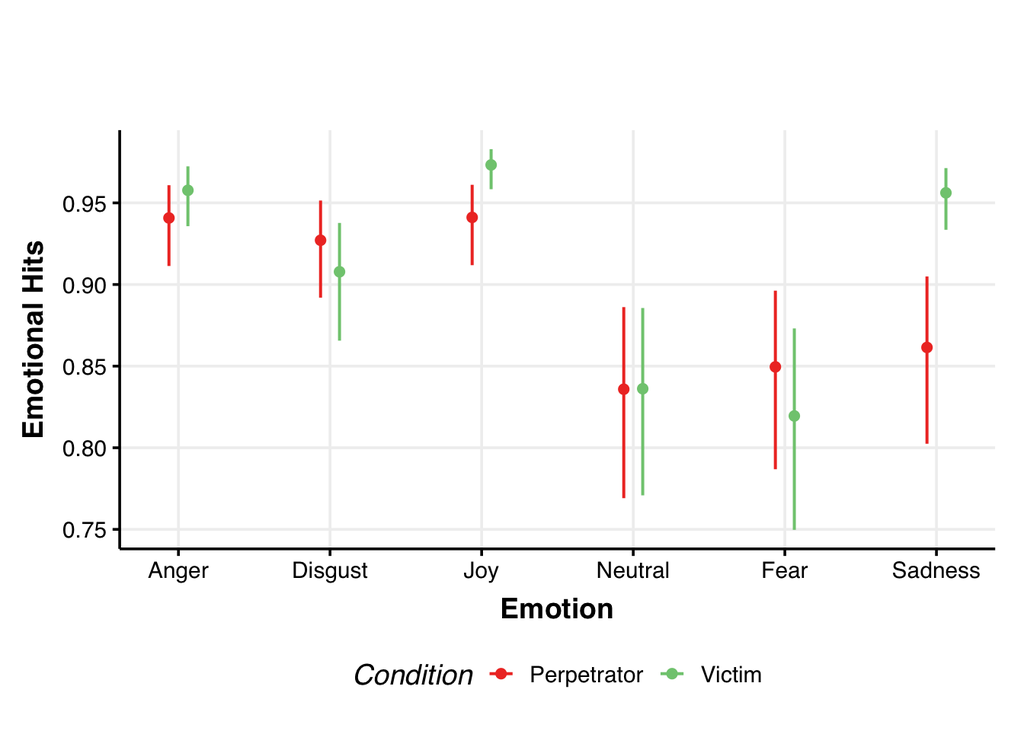

```r
plotemo = ggpredict(emo, terms = c("newemo", "condition"), ci_level = 0.95) %>%
  plot() +
  labs(x = "Emotion", y = "Emotional Hits", colour = "Condition", title = "", element_text(size = 14)) +
  scale_fill_Publication() +
  scale_colour_Publication() +
  theme_Publication() +
  scale_y_continuous(breaks = c(0.6, 0.65, 0.7, 0.75, 0.8, 0.85, 0.9, 0.95, 1))

plotemo
```

### c) Exploratory Analyses

#### Full mixed-effect model with condition

```r
class = lmer(log(rt_net) ~ condition * newclass * newemo + (1|number_ID) + (1|item),
             na.action = na.omit,
             data = data)
```

Summary

```r
tbl_regression(class,
               label = list(condition ~ "Condition",
                            newemo ~ "Emotion",
                            newclass ~ "Class of Trangression")) %>%
  modify_column_unhide(column = std.error) %>%
  modify_column_unhide(column = statistic) %>%
  modify_header(label = "**Variable**") %>%
  bold_p() %>%
  modify_fmt_fun(statistic ~ style_sigfig) %>%
  add_significance_stars(hide_ci = FALSE,
                         hide_p = FALSE,
                         pattern = "{p.value}{stars}") %>%
  add_glance_source_note(label = list(sigma ~ "\U03C3"),
                         include = c(AIC, sigma))
```

| **Variable** | **Beta** | **SE**<sup>1</sup> | **Statistic** | **95% CI**<sup>1</sup> | **p-value**<sup>2</sup> |
| --- | --- | --- | --- | --- | --- |
| Condition |  |  |  |  |  |
| Perpetrator | — | — | — | — |  |
| Victim | -0.06 | 0.052 | -1.2 | -0.16, 0.04 | 0.2 |
| Class of Trangression |  |  |  |  |  |
| Abandonment | — | — | — | — |  |
| Betrayal | -0.02 | 0.029 | -0.84 | -0.08, 0.03 | 0.4 |
| Harm | -0.03 | 0.026 | -1.3 | -0.08, 0.02 | 0.2 |
| Humiliation | 0.01 | 0.027 | 0.29 | -0.05, 0.06 | 0.8 |
| Injustice | -0.02 | 0.027 | -0.69 | -0.07, 0.03 | 0.5 |
| Emotion |  |  |  |  |  |
| Anger | — | — | — | — |  |
| Disgust | -0.01 | 0.027 | -0.22 | -0.06, 0.05 | 0.8 |
| Joy | 0.01 | 0.027 | 0.47 | -0.04, 0.07 | 0.6 |
| Neutral | 0.06 | 0.027 | 2.2 | 0.01, 0.11 | 0.026* |
| Fear | 0.05 | 0.027 | 2.0 | 0.00, 0.11 | 0.046* |
| Sadness | 0.00 | 0.027 | -0.07 | -0.05, 0.05 | >0.9 |
| Condition * Class of Trangression |  |  |  |  |  |
| Victim * Betrayal | 0.09 | 0.040 | 2.1 | 0.01, 0.17 | 0.032* |
| Victim * Harm | 0.07 | 0.036 | 2.1 | 0.00, 0.14 | 0.038* |
| Victim * Humiliation | 0.02 | 0.038 | 0.54 | -0.05, 0.09 | 0.6 |
| Victim * Injustice | 0.06 | 0.037 | 1.5 | -0.02, 0.13 | 0.13 |
| Condition * Emotion |  |  |  |  |  |
| Victim * Disgust | 0.10 | 0.038 | 2.6 | 0.02, 0.17 | 0.010** |
| Victim * Joy | -0.01 | 0.037 | -0.34 | -0.09, 0.06 | 0.7 |
| Victim * Neutral | 0.07 | 0.038 | 1.9 | 0.00, 0.15 | 0.063 |
| Victim * Fear | 0.02 | 0.038 | 0.62 | -0.05, 0.10 | 0.5 |
| Victim * Sadness | 0.01 | 0.037 | 0.27 | -0.06, 0.08 | 0.8 |
| Class of Trangression * Emotion |  |  |  |  |  |
| Betrayal * Disgust | 0.03 | 0.041 | 0.83 | -0.05, 0.11 | 0.4 |
| Harm * Disgust | 0.06 | 0.036 | 1.7 | -0.01, 0.13 | 0.089 |
| Humiliation * Disgust | 0.01 | 0.038 | 0.19 | -0.07, 0.08 | 0.8 |
| Injustice * Disgust | 0.03 | 0.038 | 0.84 | -0.04, 0.11 | 0.4 |
| Betrayal * Joy | -0.03 | 0.041 | -0.74 | -0.11, 0.05 | 0.5 |
| Harm * Joy | -0.02 | 0.036 | -0.65 | -0.09, 0.05 | 0.5 |
| Humiliation * Joy | -0.03 | 0.038 | -0.84 | -0.11, 0.04 | 0.4 |
| Injustice * Joy | -0.01 | 0.038 | -0.28 | -0.08, 0.06 | 0.8 |
| Betrayal * Neutral | 0.05 | 0.041 | 1.1 | -0.04, 0.13 | 0.3 |
| Harm * Neutral | 0.05 | 0.036 | 1.4 | -0.02, 0.12 | 0.2 |
| Humiliation * Neutral | 0.01 | 0.038 | 0.19 | -0.07, 0.08 | 0.8 |
| Injustice * Neutral | 0.10 | 0.039 | 2.6 | 0.02, 0.17 | 0.011* |
| Betrayal * Fear | 0.02 | 0.041 | 0.49 | -0.06, 0.10 | 0.6 |
| Harm * Fear | 0.03 | 0.036 | 0.84 | -0.04, 0.10 | 0.4 |
| Humiliation * Fear | 0.01 | 0.038 | 0.15 | -0.07, 0.08 | 0.9 |
| Injustice * Fear | 0.04 | 0.038 | 1.0 | -0.03, 0.11 | 0.3 |
| Betrayal * Sadness | 0.07 | 0.041 | 1.7 | -0.01, 0.15 | 0.086 |
| Harm * Sadness | 0.05 | 0.036 | 1.5 | -0.02, 0.12 | 0.14 |
| Humiliation * Sadness | 0.05 | 0.038 | 1.4 | -0.02, 0.13 | 0.2 |
| Injustice * Sadness | 0.09 | 0.038 | 2.5 | 0.02, 0.17 | 0.013* |
| Condition * Class of Trangression * Emotion |  |  |  |  |  |
| Victim * Betrayal * Disgust | -0.11 | 0.057 | -1.9 | -0.22, 0.00 | 0.056 |
| Victim * Harm * Disgust | -0.08 | 0.050 | -1.6 | -0.18, 0.02 | 0.11 |
| Victim * Humiliation * Disgust | -0.07 | 0.053 | -1.4 | -0.18, 0.03 | 0.2 |
| Victim * Injustice * Disgust | -0.10 | 0.053 | -1.8 | -0.20, 0.01 | 0.069 |
| Victim * Betrayal * Joy | -0.05 | 0.057 | -0.96 | -0.17, 0.06 | 0.3 |
| Victim * Harm * Joy | -0.04 | 0.050 | -0.79 | -0.14, 0.06 | 0.4 |
| Victim * Humiliation * Joy | -0.01 | 0.053 | -0.10 | -0.11, 0.10 | >0.9 |
| Victim * Injustice * Joy | -0.02 | 0.053 | -0.44 | -0.13, 0.08 | 0.7 |
| Victim * Betrayal * Neutral | -0.11 | 0.058 | -1.9 | -0.23, 0.00 | 0.052 |
| Victim * Harm * Neutral | -0.13 | 0.051 | -2.6 | -0.23, -0.03 | 0.009** |
| Victim * Humiliation * Neutral | -0.06 | 0.054 | -1.1 | -0.16, 0.05 | 0.3 |
| Victim * Injustice * Neutral | -0.11 | 0.054 | -2.0 | -0.21, 0.00 | 0.046* |
| Victim * Betrayal * Fear | -0.04 | 0.057 | -0.67 | -0.15, 0.07 | 0.5 |
| Victim * Harm * Fear | -0.07 | 0.050 | -1.3 | -0.16, 0.03 | 0.2 |
| Victim * Humiliation * Fear | 0.01 | 0.054 | 0.12 | -0.10, 0.11 | >0.9 |
| Victim * Injustice * Fear | 0.00 | 0.053 | 0.07 | -0.10, 0.11 | >0.9 |
| Victim * Betrayal * Sadness | -0.05 | 0.057 | -0.94 | -0.17, 0.06 | 0.3 |
| Victim * Harm * Sadness | -0.08 | 0.050 | -1.5 | -0.17, 0.02 | 0.13 |
| Victim * Humiliation * Sadness | -0.03 | 0.053 | -0.56 | -0.13, 0.07 | 0.6 |
| Victim * Injustice * Sadness | -0.09 | 0.053 | -1.6 | -0.19, 0.02 | 0.10 |

AIC = 13,180; σ = 0.333  
<sup>1</sup> SE = Standard Error, CI = Confidence Interval  
<sup>2</sup> *p<0.05; **p<0.01; ***p<0.001

Anova & conditional and marginal coefficient of determination

```r
Anova(class, type = 3, ddf = "Satterthwaite")
```

```
## Analysis of Deviance Table (Type III Wald chisquare tests)
##
## Response: log(rt_net)
##                                Chisq Df Pr(>Chisq)
## (Intercept)               34694.8368  1    < 2e-16 ***
## condition                     1.4504  1    0.22846
## newclass                      3.4014  4    0.49303
## newemo                       11.8516  5    0.03688 *
## condition:newclass            7.2342  4    0.12402
## condition:newemo             13.1671  5    0.02186 *
## newclass:newemo              22.9860 20    0.28948
## condition:newclass:newemo    16.6041 20    0.67851
## ---
## Signif. codes:  0 '***' 0.001 '**' 0.01 '*' 0.05 '.' 0.1 ' ' 1
```

```r
round(r.squaredGLMM(class, method = "marginal"), 4)
```

```
##        R2m    R2c
## [1,] 0.012 0.4407
```

- Main effect of *Emotion*
  $$\chi^2(5)
  = 11.8516, p = .037$$

Variance explained by the model:
$$R^2_m =
1.2\% \text{ (fixed)}$$
$$R^2_c =
44.07\% \text{ (fixed + random)}$$

Pairwise comparisons & estimated marginal means

```r
emmeans(class, pairwise ~ newemo, lmer.df = "asymp", type = "response", adjust = "bonferroni")
```

```
## $emmeans
##  newemo  response   SE  df asymp.LCL asymp.UCL
##  Anger        938 21.5 Inf       897       981
##  Disgust      970 22.3 Inf       927      1015
##  Joy          915 21.0 Inf       874       957
##  Neutral     1031 23.7 Inf       985      1078
##  Fear        1010 23.2 Inf       966      1057
##  Sadness      969 22.3 Inf       926      1013
##
## Results are averaged over the levels of: condition, newclass
## Degrees-of-freedom method: asymptotic
## Confidence level used: 0.95
## Intervals are back-transformed from the log scale
##
## $contrasts
##  contrast          ratio      SE  df null z.ratio p.value
##  Anger / Disgust   0.967 0.00821 Inf    1  -3.962  0.0011
##  Anger / Joy       1.025 0.00866 Inf    1   2.967  0.0452
##  Anger / Neutral   0.910 0.00779 Inf    1 -11.042  <.0001
##  Anger / Fear      0.928 0.00791 Inf    1  -8.719  <.0001
##  Anger / Sadness   0.968 0.00819 Inf    1  -3.833  0.0019
##  Disgust / Joy     1.060 0.00900 Inf    1   6.916  <.0001
##  Disgust / Neutral 0.941 0.00810 Inf    1  -7.082  <.0001
##  Disgust / Fear    0.960 0.00821 Inf    1  -4.747  <.0001
##  Disgust / Sadness 1.001 0.00851 Inf    1   0.143  1.0000
##  Joy / Neutral     0.887 0.00760 Inf    1 -13.977  <.0001
##  Joy / Fear        0.905 0.00771 Inf    1 -11.669  <.0001
##  Joy / Sadness     0.944 0.00798 Inf    1  -6.800  <.0001
##  Neutral / Fear    1.021 0.00880 Inf    1   2.360  0.2743
##  Neutral / Sadness 1.064 0.00912 Inf    1   7.253  <.0001
##  Fear / Sadness    1.043 0.00888 Inf    1   4.908  <.0001
##
## Results are averaged over the levels of: condition, newclass
## Degrees-of-freedom method: asymptotic
## P value adjustment: bonferroni method for 15 tests
## Tests are performed on the log scale
```

Plot all interaction effects

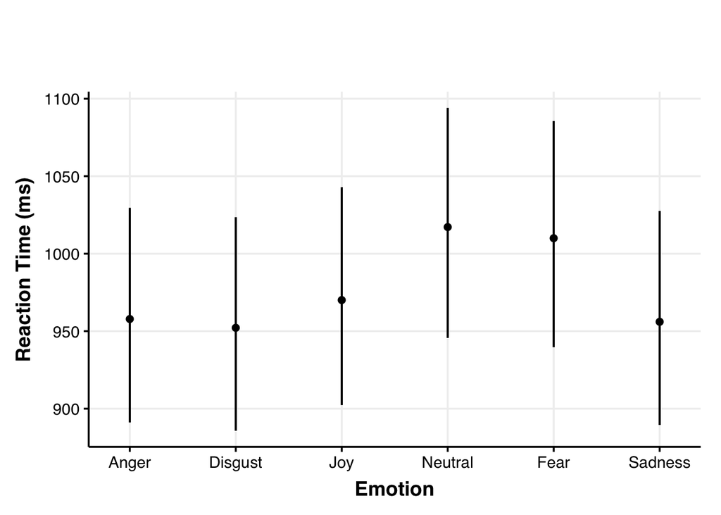

```r
plotclass = ggpredict(class, terms = c("newemo"), ci_level = 0.95) %>%
  plot() +
  labs(x = "Emotion", y = "Reaction Time (ms)", colour = "Emotion", title = "", element_text(size = 14)) +
  scale_fill_Publication() +
  scale_colour_Publication() +
  theme_Publication()

plotclass
```

#### Full mixed-effect model without condition

```r
class2 = lmer(log(rt_net) ~ newclass * newemo + (1|number_ID) + (1|item),
              na.action = na.omit,
              data = data)
summary(class2)
```

Summary

```r
tbl_regression(class2,
               label = list(newemo ~ "Emotion",
                            newclass ~ "Class of Trangression")) %>%
  modify_column_unhide(column = std.error) %>%
  modify_column_unhide(column = statistic) %>%
  modify_header(label = "**Variable**") %>%
  bold_p() %>%
  modify_fmt_fun(statistic ~ style_sigfig) %>%
  add_significance_stars(hide_ci = FALSE,
                         hide_p = FALSE,
                         pattern = "{p.value}{stars}") %>%
  add_glance_source_note(label = list(sigma ~ "\U03C3"),
                         include = c(AIC, sigma))
```

| **Variable** | **Beta** | **SE**<sup>1</sup> | **Statistic** | **95% CI**<sup>1</sup> | **p-value**<sup>2</sup> |
| --- | --- | --- | --- | --- | --- |
| Class of Trangression |  |  |  |  |  |
| Abandonment | — | — | — | — |  |
| Betrayal | 0.02 | 0.020 | 0.99 | -0.02, 0.06 | 0.3 |
| Harm | 0.00 | 0.018 | 0.22 | -0.03, 0.04 | 0.8 |
| Humiliation | 0.02 | 0.019 | 0.93 | -0.02, 0.06 | 0.4 |
| Injustice | 0.01 | 0.019 | 0.52 | -0.03, 0.05 | 0.6 |
| Emotion |  |  |  |  |  |
| Anger | — | — | — | — |  |
| Disgust | 0.04 | 0.019 | 2.3 | 0.01, 0.08 | 0.023* |
| Joy | 0.01 | 0.019 | 0.30 | -0.03, 0.04 | 0.8 |
| Neutral | 0.10 | 0.019 | 5.1 | 0.06, 0.13 | <0.001*** |
| Fear | 0.06 | 0.019 | 3.4 | 0.03, 0.10 | <0.001*** |
| Sadness | 0.00 | 0.019 | 0.14 | -0.03, 0.04 | 0.9 |
| Class of Trangression * Emotion |  |  |  |  |  |
| Betrayal * Disgust | -0.02 | 0.029 | -0.73 | -0.08, 0.04 | 0.5 |
| Harm * Disgust | 0.02 | 0.025 | 0.82 | -0.03, 0.07 | 0.4 |
| Humiliation * Disgust | -0.03 | 0.027 | -1.1 | -0.08, 0.02 | 0.3 |
| Injustice * Disgust | -0.02 | 0.027 | -0.63 | -0.07, 0.04 | 0.5 |
| Betrayal * Joy | -0.06 | 0.028 | -2.0 | -0.11, 0.00 | 0.041* |
| Harm * Joy | -0.04 | 0.025 | -1.7 | -0.09, 0.01 | 0.090 |
| Humiliation * Joy | -0.03 | 0.027 | -1.3 | -0.09, 0.02 | 0.2 |
| Injustice * Joy | -0.02 | 0.026 | -0.83 | -0.07, 0.03 | 0.4 |
| Betrayal * Neutral | -0.01 | 0.029 | -0.43 | -0.07, 0.04 | 0.7 |
| Harm * Neutral | -0.02 | 0.025 | -0.71 | -0.07, 0.03 | 0.5 |
| Humiliation * Neutral | -0.02 | 0.027 | -0.81 | -0.07, 0.03 | 0.4 |
| Injustice * Neutral | 0.04 | 0.027 | 1.6 | -0.01, 0.10 | 0.11 |
| Betrayal * Fear | 0.00 | 0.029 | 0.01 | -0.06, 0.06 | >0.9 |
| Harm * Fear | 0.00 | 0.025 | -0.14 | -0.05, 0.05 | 0.9 |
| Humiliation * Fear | 0.01 | 0.027 | 0.33 | -0.04, 0.06 | 0.7 |
| Injustice * Fear | 0.04 | 0.027 | 1.5 | -0.01, 0.09 | 0.13 |
| Betrayal * Sadness | 0.04 | 0.028 | 1.5 | -0.01, 0.10 | 0.14 |
| Harm * Sadness | 0.01 | 0.025 | 0.60 | -0.03, 0.06 | 0.6 |
| Humiliation * Sadness | 0.04 | 0.026 | 1.4 | -0.01, 0.09 | 0.2 |
| Injustice * Sadness | 0.05 | 0.026 | 1.9 | 0.00, 0.10 | 0.060 |

AIC = 13,006; σ = 0.333  
<sup>1</sup> SE = Standard Error, CI = Confidence Interval  
<sup>2</sup> *p<0.05; **p<0.01; ***p<0.001

Anova & conditional and marginal coefficient of determination

```r
Anova(class2, type = 3)
```

```
## Analysis of Deviance Table (Type III Wald chisquare tests)
##
## Response: log(rt_net)
##                      Chisq Df Pr(>Chisq)
## (Intercept)     69581.3344  1  < 2.2e-16 ***
## newclass            1.5656  4    0.81495
## newemo             43.6176  5  2.769e-08 ***
## newclass:newemo    40.6012 20    0.00419 **
## ---
## Signif. codes:  0 '***' 0.001 '**' 0.01 '*' 0.05 '.' 0.1 ' ' 1
```

```r
round(r.squaredGLMM(class2, method = "marginal"), 4)
```

```
##         R2m    R2c
## [1,] 0.0099 0.4383
```

Variance explained by the model:
$$R^2_m =
0.99\% \text{ (fixed)}$$
$$R^2_c =
43.83\% \text{ (fixed + random)}$$

#### Difference between the two models

```r
anova(class, class2)
```

```
## Data: data
## Models:
## class2: log(rt_net) ~ newclass * newemo + (1 | number_ID) + (1 | item)
## class: log(rt_net) ~ condition * newclass * newemo + (1 | number_ID) + (1 | item)
##        npar   AIC   BIC  logLik deviance  Chisq Df Pr(>Chisq)
## class2   33 12807 13066 -6370.6    12741
## class    63 12823 13317 -6348.4    12697 44.335 30    0.04445 *
## ---
## Signif. codes:  0 '***' 0.001 '**' 0.01 '*' 0.05 '.' 0.1 ' ' 1
```

```r
lrtest(class2, class)
```

```
## Likelihood ratio test
##
## Model 1: log(rt_net) ~ newclass * newemo + (1 | number_ID) + (1 | item)
## Model 2: log(rt_net) ~ condition * newclass * newemo + (1 | number_ID) +
##     (1 | item)
##   #Df  LogLik Df  Chisq Pr(>Chisq)
## 1  33 -6470.0
## 2  63 -6526.8 30 113.49  1.234e-11 ***
## ---
## Signif. codes:  0 '***' 0.001 '**' 0.01 '*' 0.05 '.' 0.1 ' ' 1
```

#### RT with Condition and Class (preregistered)

```r
exprt1 = lmer(log(rt_net) ~ condition * newclass + (1|number_ID) + (1|item),
           na.action = na.omit,
           data = data)
```

Summary

```r
tbl_regression(exprt1,
               label = list(condition ~ "Condition",
                            newclass ~ "Class of Trangression")) %>%
  modify_column_unhide(column = std.error) %>%
  modify_column_unhide(column = statistic) %>%
  modify_header(label = "**Variable**") %>%
  bold_p() %>%
  modify_fmt_fun(statistic ~ style_sigfig) %>%
  add_significance_stars(hide_ci = FALSE,
                         hide_p = FALSE,
                         pattern = "{p.value}{stars}") %>%
  add_glance_source_note(label = list(sigma ~ "\U03C3"),
                         include = c(AIC, sigma))
```

| **Variable** | **Beta** | **SE**<sup>1</sup> | **Statistic** | **95% CI**<sup>1</sup> | **p-value**<sup>2</sup> |
| --- | --- | --- | --- | --- | --- |
| Condition |  |  |  |  |  |
| Perpetrator | — | — | — | — |  |
| Victim | -0.03 | 0.046 | -0.69 | -0.12, 0.06 | 0.5 |
| Class of Trangression |  |  |  |  |  |
| Abandonment | — | — | — | — |  |
| Betrayal | 0.00 | 0.013 | -0.09 | -0.03, 0.02 | >0.9 |
| Harm | -0.01 | 0.011 | -0.47 | -0.03, 0.02 | 0.6 |
| Humiliation | 0.01 | 0.012 | 1.3 | -0.01, 0.04 | 0.2 |
| Injustice | 0.02 | 0.012 | 1.9 | 0.00, 0.05 | 0.063 |
| Condition * Class of Trangression |  |  |  |  |  |
| Victim * Betrayal | 0.03 | 0.017 | 1.5 | -0.01, 0.06 | 0.13 |
| Victim * Harm | 0.01 | 0.015 | 0.62 | -0.02, 0.04 | 0.5 |
| Victim * Humiliation | -0.01 | 0.016 | -0.35 | -0.04, 0.03 | 0.7 |
| Victim * Injustice | 0.00 | 0.015 | 0.32 | -0.03, 0.04 | 0.7 |

AIC = 13,146; σ = 0.335  
<sup>1</sup> SE = Standard Error, CI = Confidence Interval  
<sup>2</sup> *p<0.05; **p<0.01; ***p<0.001

Anova & conditional and marginal coefficient of determination

```r
Anova(exprt1, type = 3)
```

```
## Analysis of Deviance Table (Type III Wald chisquare tests)
##
## Response: log(rt_net)
##                         Chisq Df Pr(>Chisq)
## (Intercept)        44601.1451  1     <2e-16 ***
## condition              0.4774  1     0.4896
## newclass               8.3150  4     0.0807 .
## condition:newclass     3.7470  4     0.4413
## ---
## Signif. codes:  0 '***' 0.001 '**' 0.01 '*' 0.05 '.' 0.1 ' ' 1
```

```r
round(r.squaredGLMM(exprt1, method = "marginal"), 4)
```

```
##         R2m  R2c
## [1,] 0.0014 0.43
```

No significant effect

Variance explained by the model:
$$R^2_m =
0.14\% \text{ (fixed)}$$
$$R^2_c =
43.00\% \text{ (fixed + random)}$$

#### Emotional Hits with Condition and Class (preregistered)

```r
exphit1 = glmer(score ~ condition * newclass + (1|number_ID) + (1|item),
          na.action = na.omit,
          data = data,
          family = binomial,
          control = glmerControl(optimizer = "bobyqa"))
```

Summary

```r
tbl_regression(exphit1,
               label = list(condition ~ "Condition",
                            newclass ~ "Class of Transgression")) %>%
  modify_column_unhide(column = std.error) %>%
  modify_column_unhide(column = statistic) %>%
  modify_header(label = "**Variable**") %>%
  bold_p() %>%
  modify_fmt_fun(statistic ~ style_sigfig) %>%
  add_significance_stars(hide_ci = FALSE,
                         hide_p = FALSE,
                         pattern = "{p.value}{stars}") %>%
  add_glance_source_note(label = list(sigma ~ "\U03C3"),
                         include = c(AIC, sigma))
```

| **Variable** | **log(OR)**<sup>1</sup> | **SE**<sup>1</sup> | **Statistic** | **95% CI**<sup>1</sup> | **p-value**<sup>2</sup> |
| --- | --- | --- | --- | --- | --- |
| Condition |  |  |  |  |  |
| Perpetrator | — | — | — | — |  |
| Victim | 0.08 | 0.280 | 0.28 | -0.47, 0.63 | 0.8 |
| Class of Transgression |  |  |  |  |  |
| Abandonment | — | — | — | — |  |
| Betrayal | -0.08 | 0.128 | -0.60 | -0.33, 0.17 | 0.6 |
| Harm | 0.31 | 0.118 | 2.6 | 0.08, 0.54 | 0.008** |
| Humiliation | -0.04 | 0.117 | -0.33 | -0.27, 0.19 | 0.7 |
| Injustice | -0.19 | 0.122 | -1.6 | -0.43, 0.05 | 0.12 |
| Condition * Class of Transgression |  |  |  |  |  |
| Victim * Betrayal | -0.01 | 0.141 | -0.09 | -0.29, 0.26 | >0.9 |
| Victim * Harm | 0.32 | 0.132 | 2.4 | 0.06, 0.58 | 0.015* |
| Victim * Humiliation | 0.06 | 0.132 | 0.47 | -0.20, 0.32 | 0.6 |
| Victim * Injustice | 0.21 | 0.130 | 1.6 | -0.05, 0.46 | 0.11 |

AIC = 14,895; σ = 1.00  
<sup>1</sup> OR = Odds Ratio, SE = Standard Error, CI = Confidence Interval  
<sup>2</sup> *p<0.05; **p<0.01; ***p<0.001

Anova & conditional and marginal coefficient of determination

```r
Anova(exphit1, type = 3)
```

```
## Analysis of Deviance Table (Type III Wald chisquare tests)
##
## Response: score
##                       Chisq Df Pr(>Chisq)
## (Intercept)        102.7702  1  < 2.2e-16 ***
## condition            0.0762  1  0.7825761
## newclass            20.1935  4  0.0004573 ***
## condition:newclass   9.2906  4  0.0542316 .
## ---
## Signif. codes:  0 '***' 0.001 '**' 0.01 '*' 0.05 '.' 0.1 ' ' 1
```

```r
round(r.squaredGLMM(exphit1, method = "marginal"), 4)
```

```
##                R2m    R2c
## theoretical 0.0106 0.4753
## delta       0.0069 0.3083
```

- Main effect of *Class*
  $$\chi^2(4) =
  20.194, p < .001$$

Variance explained by the model:
$$R^2_m =
0.69\% \text{ (fixed)}$$
$$R^2_c =
30.83\% \text{ (fixed + random)}$$

Pairwise comparisons (estimated marginal means and pairwise comparisons)

```r
emmeans(exphit1, pairwise ~ newclass, lmer.df = "asymp", type = "response", adjust = "bonferroni")
```

```
## $emmeans
##  newclass     prob     SE  df asymp.LCL asymp.UCL
##  Abandonment 0.895 0.0141 Inf     0.864     0.920
##  Betrayal    0.887 0.0155 Inf     0.853     0.914
##  Harm        0.932 0.0096 Inf     0.910     0.948
##  Humiliation 0.894 0.0141 Inf     0.863     0.919
##  Injustice   0.887 0.0153 Inf     0.853     0.913
##
## Results are averaged over the levels of: condition
## Confidence level used: 0.95
## Intervals are back-transformed from the logit scale
##
## $contrasts
##  contrast                  odds.ratio     SE  df null z.ratio p.value
##  Abandonment / Betrayal         1.086 0.1111 Inf    1   0.808  1.0000
##  Abandonment / Harm             0.624 0.0625 Inf    1  -4.705  <.0001
##  Abandonment / Humiliation      1.008 0.0929 Inf    1   0.086  1.0000
##  Abandonment / Injustice        1.090 0.1125 Inf    1   0.835  1.0000
##  Betrayal / Harm                0.575 0.0616 Inf    1  -5.166  <.0001
##  Betrayal / Humiliation         0.928 0.0931 Inf    1  -0.745  1.0000
##  Betrayal / Injustice           1.004 0.1105 Inf    1   0.032  1.0000
##  Harm / Humiliation             1.615 0.1609 Inf    1   4.810  <.0001
##  Harm / Injustice               1.746 0.1822 Inf    1   5.343  <.0001
##  Humiliation / Injustice        1.081 0.1111 Inf    1   0.762  1.0000
##
## Results are averaged over the levels of: condition
## P value adjustment: bonferroni method for 10 tests
## Tests are performed on the log odds ratio scale
```

Plot all interaction effects

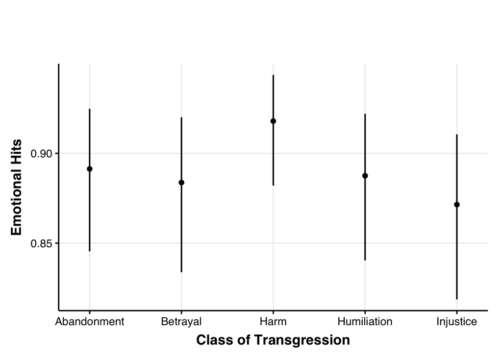

```r
plotexphit1 = ggpredict(exphit1, terms = c("newclass"), ci_level = 0.95) %>%
  plot() +
  labs(x = "Class of Transgression", y = "Emotional Hits", colour = "Class of Transgression", title = "", element_text(size = 14)) +
  scale_fill_Publication() +
  scale_colour_Publication() +
  theme_Publication() +
  scale_y_continuous(breaks = c(0.6, 0.65, 0.7, 0.75, 0.8, 0.85, 0.9, 0.95, 1))

plotexphit1
```

Full mixed-effect model

```r
fullcov = lmer(log(rt_net) ~ condition * newemo + age + newgender + political_orientation + (1|number_ID) + (1|item),
           na.action = na.omit,
           data = data)
```

Summary

```r
tbl_regression(fullcov,
               label = list(condition ~ "Condition",
                            newemo ~ "Emotion",
                            age ~ "Age",
                            newgender ~ "Sex",
                            political_orientation ~ "Political Orientation (1-Liberal to 7-Conservative)")) %>%
  modify_column_unhide(column = std.error) %>%
  modify_column_unhide(column = statistic) %>%
  modify_header(label = "**Variable**") %>%
  bold_p() %>%
  modify_fmt_fun(statistic ~ style_sigfig) %>%
  add_significance_stars(hide_ci = FALSE,
                         hide_p = FALSE,
                         pattern = "{p.value}{stars}") %>%
  add_glance_source_note(label = list(sigma ~ "\U03C3"),
                         include = c(AIC, sigma))
```

| **Variable** | **Beta** | **SE**<sup>1</sup> | **Statistic** | **95% CI**<sup>1</sup> | **p-value**<sup>2</sup> |
| --- | --- | --- | --- | --- | --- |
| Condition |  |  |  |  |  |
| Perpetrator | — | — | — | — |  |
| Victim | -0.01 | 0.047 | -0.23 | -0.10, 0.08 | 0.8 |
| Emotion |  |  |  |  |  |
| Anger | — | — | — | — |  |
| Disgust | 0.02 | 0.012 | 1.8 | 0.00, 0.05 | 0.069 |
| Joy | -0.01 | 0.012 | -0.50 | -0.03, 0.02 | 0.6 |
| Neutral | 0.10 | 0.012 | 8.0 | 0.07, 0.12 | <0.001*** |
| Fear | 0.07 | 0.012 | 6.1 | 0.05, 0.10 | <0.001*** |
| Sadness | 0.05 | 0.012 | 4.3 | 0.03, 0.08 | <0.001*** |
| Age | 0.00 | 0.002 | 0.63 | 0.00, 0.00 | 0.5 |
| Sex |  |  |  |  |  |
| Female | — | — | — | — |  |
| Male | 0.00 | 0.047 | -0.07 | -0.10, 0.09 | >0.9 |
| Political Orientation (1-Liberal to 7-Conservative) |  |  |  |  |  |
| 1 | — | — | — | — |  |
| 2 | -0.07 | 0.079 | -0.88 | -0.23, 0.09 | 0.4 |
| 3 | -0.07 | 0.092 | -0.78 | -0.25, 0.11 | 0.4 |
| 4 | 0.00 | 0.082 | 0.00 | -0.16, 0.16 | >0.9 |
| 5 | -0.04 | 0.093 | -0.38 | -0.22, 0.15 | 0.7 |
| 6 | 0.08 | 0.102 | 0.79 | -0.12, 0.28 | 0.4 |
| 7 | -0.21 | 0.124 | -1.7 | -0.46, 0.04 | 0.094 |
| Condition * Emotion |  |  |  |  |  |
| Victim * Disgust | 0.03 | 0.017 | 1.7 | 0.00, 0.06 | 0.084 |
| Victim * Joy | -0.04 | 0.017 | -2.2 | -0.07, 0.00 | 0.030* |
| Victim * Neutral | -0.01 | 0.017 | -0.52 | -0.04, 0.02 | 0.6 |
| Victim * Fear | 0.00 | 0.017 | 0.28 | -0.03, 0.04 | 0.8 |
| Victim * Sadness | -0.04 | 0.017 | -2.3 | -0.07, -0.01 | 0.020* |

AIC = 12,828; σ = 0.333  
<sup>1</sup> SE = Standard Error, CI = Confidence Interval  
<sup>2</sup> *p<0.05; **p<0.01; ***p<0.001

Anova & conditional and marginal coefficient of determination

```r
Anova(fullcov, type = 3, ddf = "Satterthwaite")
```

```
## Analysis of Deviance Table (Type III Wald chisquare tests)
##
## Response: log(rt_net)
##                           Chisq Df Pr(>Chisq)
## (Intercept)           4920.5044  1  < 2.2e-16 ***
## condition                0.0525  1  0.8187078
## newemo                 117.2043  5  < 2.2e-16 ***
## age                      0.3917  1  0.5314247
## newgender                0.0048  1  0.9447705
## political_orientation    6.8878  6  0.3313502
## condition:newemo        23.8544  5  0.0002316 ***
## ---
## Signif. codes:  0 '***' 0.001 '**' 0.01 '*' 0.05 '.' 0.1 ' ' 1
```

```r
round(r.squaredGLMM(fullcov, method = "marginal"), 4)
```

```
##         R2m    R2c
## [1,] 0.0277 0.4524
```

- Main effect of *Emotion*
  $$\chi^2(5)
  = 117.204, p < .001$$
- Interaction of *Emotion* and *Condition*
  $$\chi^2(5) = 23.854, p < .001$$

Pairwise comparisons (estimated marginal means and pairwise comparisons)

```r
emmeans(fullcov, pairwise ~ newemo, lmer.df = "asymp", type = "response", adjust = "bonferroni")
```

```
## $emmeans
##  newemo  response   SE  df asymp.LCL asymp.UCL
##  Anger        929 24.9 Inf       881       979
##  Disgust      963 25.9 Inf       914      1015
##  Joy          906 24.3 Inf       860       955
##  Neutral     1020 27.4 Inf       968      1075
##  Fear        1001 26.9 Inf       950      1056
##  Sadness      959 25.7 Inf       910      1011
##
## Results are averaged over the levels of: condition, newgender, political_orientation
## Degrees-of-freedom method: asymptotic
## Confidence level used: 0.95
## Intervals are back-transformed from the log scale
##
## $contrasts
##  contrast          ratio      SE  df null z.ratio p.value
##  Anger / Disgust   0.964 0.00814 Inf    1  -4.328  0.0002
##  Anger / Joy       1.025 0.00860 Inf    1   2.886  0.0585
##  Anger / Neutral   0.910 0.00775 Inf    1 -11.016  <.0001
##  Anger / Fear      0.927 0.00785 Inf    1  -8.929  <.0001
##  Anger / Sadness   0.968 0.00814 Inf    1  -3.812  0.0021
##  Disgust / Joy     1.063 0.00895 Inf    1   7.212  <.0001
##  Disgust / Neutral 0.944 0.00807 Inf    1  -6.699  <.0001
##  Disgust / Fear    0.962 0.00817 Inf    1  -4.598  0.0001
##  Disgust / Sadness 1.004 0.00847 Inf    1   0.532  1.0000
##  Joy / Neutral     0.889 0.00755 Inf    1 -13.890  <.0001
##  Joy / Fear        0.905 0.00765 Inf    1 -11.814  <.0001
##  Joy / Sadness     0.945 0.00793 Inf    1  -6.707  <.0001
##  Neutral / Fear    1.018 0.00872 Inf    1   2.122  0.5078
##  Neutral / Sadness 1.064 0.00905 Inf    1   7.255  <.0001
##  Fear / Sadness    1.045 0.00884 Inf    1   5.147  <.0001
##
## Results are averaged over the levels of: condition, newgender, political_orientation
## Degrees-of-freedom method: asymptotic
## P value adjustment: bonferroni method for 15 tests
## Tests are performed on the log scale
```

```r
emmeans(fullcov, pairwise ~ newemo|condition, lmer.df = "asymp", type = "response", adjust = "bonferroni")
```

```
## $emmeans
## condition = Perpetrator:
##  newemo  response   SE  df asymp.LCL asymp.UCL
##  Anger        934 34.0 Inf       869      1003
##  Disgust      954 34.8 Inf       889      1025
##  Joy          928 33.8 Inf       864       997
##  Neutral     1030 37.6 Inf       959      1106
##  Fear        1005 36.6 Inf       935      1079
##  Sadness      983 35.8 Inf       915      1056
##
## condition = Victim:
##  newemo  response   SE  df asymp.LCL asymp.UCL
##  Anger        924 32.5 Inf       862       990
##  Disgust      972 34.3 Inf       907      1042
##  Joy          885 31.2 Inf       826       948
##  Neutral     1010 35.6 Inf       942      1082
##  Fear         998 35.2 Inf       932      1070
##  Sadness      935 32.9 Inf       873      1002
##
## Results are averaged over the levels of: newgender, political_orientation
## Degrees-of-freedom method: asymptotic
## Confidence level used: 0.95
## Intervals are back-transformed from the log scale
##
## $contrasts
## condition = Perpetrator:
##  contrast          ratio     SE  df null z.ratio p.value
##  Anger / Disgust   0.978 0.0118 Inf    1  -1.820  1.0000
##  Anger / Joy       1.006 0.0121 Inf    1   0.500  1.0000
##  Anger / Neutral   0.906 0.0111 Inf    1  -8.047  <.0001
##  Anger / Fear      0.929 0.0112 Inf    1  -6.084  <.0001
##  Anger / Sadness   0.950 0.0114 Inf    1  -4.286  0.0003
##  Disgust / Joy     1.028 0.0124 Inf    1   2.321  0.3046
##  Disgust / Neutral 0.927 0.0113 Inf    1  -6.236  <.0001
##  Disgust / Fear    0.950 0.0115 Inf    1  -4.253  0.0003
##  Disgust / Sadness 0.971 0.0117 Inf    1  -2.461  0.2077
##  Joy / Neutral     0.901 0.0110 Inf    1  -8.551  <.0001
##  Joy / Fear        0.924 0.0111 Inf    1  -6.591  <.0001
##  Joy / Sadness     0.944 0.0114 Inf    1  -4.791  <.0001
##  Neutral / Fear    1.025 0.0125 Inf    1   2.044  0.6148
```

[output cut: 10 more lines]

```
##  Disgust / Joy     1.098 0.0129 Inf    1   7.939  <.0001
##  Disgust / Neutral 0.963 0.0115 Inf    1  -3.202  0.0205
##  Disgust / Fear    0.974 0.0116 Inf    1  -2.241  0.3754
##  Disgust / Sadness 1.039 0.0122 Inf    1   3.284  0.0153
##  Joy / Neutral     0.877 0.0104 Inf    1 -11.131  <.0001
##  Joy / Fear        0.887 0.0105 Inf    1 -10.138  <.0001
##  Joy / Sadness     0.947 0.0111 Inf    1  -4.694  <.0001
##  Neutral / Fear    1.011 0.0122 Inf    1   0.949  1.0000
##  Neutral / Sadness 1.080 0.0128 Inf    1   6.496  <.0001
##  Fear / Sadness    1.068 0.0127 Inf    1   5.518  <.0001
##
## Results are averaged over the levels of: newgender, political_orientation
## Degrees-of-freedom method: asymptotic
## P value adjustment: bonferroni method for 15 tests
## Tests are performed on the log scale
```

Plot all interaction effects

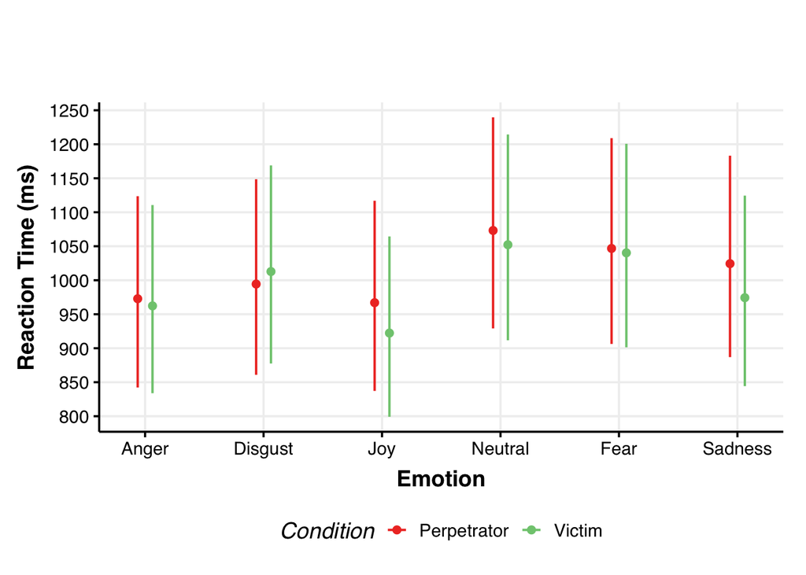

```r
plotfullcov = ggpredict(fullcov, terms = c("newemo", "condition"), ci_level = 0.95) %>%
  plot() +
  labs(x = "Emotion", y = "Reaction Time (ms)", colour = "Condition", title = "", element_text(size = 14)) +
  scale_fill_Publication() +
  scale_colour_Publication() +
  theme_Publication() +
  scale_y_continuous(breaks = c(800, 850, 900, 950, 1000, 1050, 1100, 1150, 1200, 1250))

plotfullcov
```

Full mixed-effect model

```r
emocov = glmer(score ~ newemo * condition + age + newgender + political_orientation + (1|number_ID) + (1|item),
          data = data,
          family = binomial,
          na.action = na.omit,
          control = glmerControl(optimizer = "bobyqa"))
```

Summary

```r
tbl_regression(emocov,
               label = list(condition ~ "Condition",
                            newemo ~ "Emotion",
                            age ~ "Age",
                            newgender ~ "Sex",
                            political_orientation ~ "Political Orientation (1-Liberal to 7-Conservative)")) %>%
  modify_column_unhide(column = std.error) %>%
  modify_column_unhide(column = statistic) %>%
  modify_header(label = "**Variable**") %>%
  bold_p() %>%
  modify_fmt_fun(statistic ~ style_sigfig) %>%
  add_significance_stars(hide_ci = FALSE,
                         hide_p = FALSE,
                         pattern = "{p.value}{stars}") %>%
  add_glance_source_note(label = list(sigma ~ "\U03C3"),
                         include = c(AIC, sigma))
```

| **Variable** | **log(OR)**<sup>1</sup> | **SE**<sup>1</sup> | **Statistic** | **95% CI**<sup>1</sup> | **p-value**<sup>2</sup> |
| --- | --- | --- | --- | --- | --- |
| Emotion |  |  |  |  |  |
| Anger | — | — | — | — |  |
| Disgust | -0.23 | 0.109 | -2.1 | -0.44, -0.01 | 0.037* |
| Joy | 0.00 | 0.112 | 0.01 | -0.22, 0.22 | >0.9 |
| Neutral | -1.1 | 0.104 | -11 | -1.3, -0.94 | <0.001*** |
| Fear | -1.0 | 0.104 | -10 | -1.2, -0.84 | <0.001*** |
| Sadness | -0.94 | 0.105 | -9.0 | -1.1, -0.74 | <0.001*** |
| Condition |  |  |  |  |  |
| Perpetrator | — | — | — | — |  |
| Victim | 0.39 | 0.299 | 1.3 | -0.19, 0.98 | 0.2 |
| Age | -0.02 | 0.010 | -2.3 | -0.04, 0.00 | 0.022* |
| Sex |  |  |  |  |  |
| Female | — | — | — | — |  |
| Male | -0.09 | 0.280 | -0.31 | -0.64, 0.46 | 0.8 |
| Political Orientation (1-Liberal to 7-Conservative) |  |  |  |  |  |
| 1 | — | — | — | — |  |
| 2 | 0.54 | 0.474 | 1.1 | -0.39, 1.5 | 0.3 |
| 3 | 0.55 | 0.551 | 1.0 | -0.53, 1.6 | 0.3 |
| 4 | -0.12 | 0.491 | -0.24 | -1.1, 0.84 | 0.8 |
| 5 | 0.53 | 0.557 | 0.94 | -0.57, 1.6 | 0.3 |
| 6 | 0.59 | 0.608 | 0.97 | -0.60, 1.8 | 0.3 |
| 7 | -0.43 | 0.743 | -0.58 | -1.9, 1.0 | 0.6 |
| Emotion * Condition |  |  |  |  |  |
| Disgust * Victim | -0.62 | 0.165 | -3.8 | -0.94, -0.30 | <0.001*** |
| Joy * Victim | 0.51 | 0.188 | 2.7 | 0.14, 0.88 | 0.006** |
| Neutral * Victim | -0.38 | 0.157 | -2.4 | -0.69, -0.08 | 0.015* |
| Fear * Victim | -0.60 | 0.157 | -3.9 | -0.91, -0.30 | <0.001*** |
| Sadness * Victim | 0.88 | 0.171 | 5.1 | 0.54, 1.2 | <0.001*** |

AIC = 13,995; σ = 1.00  
<sup>1</sup> OR = Odds Ratio, SE = Standard Error, CI = Confidence Interval  
<sup>2</sup> *p<0.05; **p<0.01; ***p<0.001

Anova & conditional and marginal coefficient of determination

```r
Anova(emocov, type = 3, ddf = "Satterthwaite")
```

```
## Analysis of Deviance Table (Type III Wald chisquare tests)
##
## Response: score
##                          Chisq Df Pr(>Chisq)
## (Intercept)            32.1993  1  1.391e-08 ***
## newemo                265.8489  5  < 2.2e-16 ***
## condition               1.7215  1    0.18950
## age                     5.2755  1    0.02163 *
## newgender               0.0974  1    0.75491
## political_orientation   5.8882  6    0.43583
## newemo:condition      149.0108  5  < 2.2e-16 ***
## ---
## Signif. codes:  0 '***' 0.001 '**' 0.01 '*' 0.05 '.' 0.1 ' ' 1
```

```r
round(r.squaredGLMM(emocov, method = "marginal"), 4)
```

```
##                R2m    R2c
## theoretical 0.1062 0.5291
## delta       0.0715 0.3560
```

Variance explained by the model:
$$R^2_m =
7.16\% \text{ (fixed)}$$
$$R^2_c =
35.59\% \text{ (fixed + random)}$$

Pairwise comparisons (estimated marginal means and pairwise comparisons)

```r
emmeans(emocov, pairwise ~ newemo, lmer.df = "asymp", type = "response", adjust = "bonferroni")
```

```
## $emmeans
##  newemo   prob      SE  df asymp.LCL asymp.UCL
##  Anger   0.947 0.00897 Inf     0.926     0.962
##  Disgust 0.912 0.01400 Inf     0.881     0.936
##  Joy     0.958 0.00722 Inf     0.942     0.970
##  Neutral 0.824 0.02500 Inf     0.770     0.868
##  Fear    0.823 0.02511 Inf     0.768     0.867
##  Sadness 0.915 0.01374 Inf     0.884     0.938
##
## Results are averaged over the levels of: condition, newgender, political_orientation
## Confidence level used: 0.95
## Intervals are back-transformed from the logit scale
##
## $contrasts
##  contrast          odds.ratio     SE  df null z.ratio p.value
##  Anger / Disgust        1.713 0.1410 Inf    1   6.539  <.0001
##  Anger / Joy            0.773 0.0725 Inf    1  -2.741  0.0917
##  Anger / Neutral        3.805 0.2989 Inf    1  17.011  <.0001
##  Anger / Fear           3.832 0.3006 Inf    1  17.123  <.0001
##  Anger / Sadness        1.658 0.1415 Inf    1   5.927  <.0001
##  Disgust / Joy          0.451 0.0399 Inf    1  -8.998  <.0001
##  Disgust / Neutral      2.221 0.1578 Inf    1  11.229  <.0001
##  Disgust / Fear         2.237 0.1586 Inf    1  11.351  <.0001
##  Disgust / Sadness      0.968 0.0765 Inf    1  -0.410  1.0000
##  Joy / Neutral          4.921 0.4183 Inf    1  18.743  <.0001
##  Joy / Fear             4.956 0.4209 Inf    1  18.846  <.0001
##  Joy / Sadness          2.145 0.1953 Inf    1   8.379  <.0001
##  Neutral / Fear         1.007 0.0660 Inf    1   0.108  1.0000
##  Neutral / Sadness      0.436 0.0325 Inf    1 -11.126  <.0001
##  Fear / Sadness         0.433 0.0323 Inf    1 -11.231  <.0001
##
## Results are averaged over the levels of: condition, newgender, political_orientation
## P value adjustment: bonferroni method for 15 tests
## Tests are performed on the log odds ratio scale
```

```r
emmeans(emocov, pairwise ~ condition, lmer.df = "asymp", type = "response", adjust = "bonferroni")
```

```
## $emmeans
##  condition    prob     SE  df asymp.LCL asymp.UCL
##  Perpetrator 0.893 0.0210 Inf     0.845     0.928
##  Victim      0.923 0.0152 Inf     0.887     0.948
##
## Results are averaged over the levels of: newemo, newgender, political_orientation
## Confidence level used: 0.95
## Intervals are back-transformed from the logit scale
##
## $contrasts
##  contrast             odds.ratio    SE  df null z.ratio p.value
##  Perpetrator / Victim        0.7 0.193 Inf    1  -1.296  0.1951
##
## Results are averaged over the levels of: newemo, newgender, political_orientation
## Tests are performed on the log odds ratio scale
```

```r
emmeans(emocov, pairwise ~ newemo|condition, lmer.df = "asymp", type = "response", adjust = "bonferroni")
```

```
## $emmeans
## condition = Perpetrator:
##  newemo   prob     SE  df asymp.LCL asymp.UCL
##  Anger   0.936 0.0139 Inf     0.903     0.959
##  Disgust 0.921 0.0169 Inf     0.881     0.948
##  Joy     0.936 0.0139 Inf     0.903     0.959
##  Neutral 0.823 0.0331 Inf     0.749     0.879
##  Fear    0.838 0.0310 Inf     0.768     0.890
##  Sadness 0.851 0.0290 Inf     0.784     0.899
##
## condition = Victim:
##  newemo   prob     SE  df asymp.LCL asymp.UCL
##  Anger   0.956 0.0098 Inf     0.932     0.972
##  Disgust 0.903 0.0197 Inf     0.857     0.935
##  Joy     0.973 0.0063 Inf     0.958     0.983
##  Neutral 0.825 0.0318 Inf     0.754     0.879
##  Fear    0.807 0.0342 Inf     0.731     0.865
##  Sadness 0.953 0.0104 Inf     0.928     0.970
##
## Results are averaged over the levels of: newgender, political_orientation
## Confidence level used: 0.95
## Intervals are back-transformed from the logit scale
##
## $contrasts
## condition = Perpetrator:
##  contrast          odds.ratio     SE  df null z.ratio p.value
##  Anger / Disgust        1.256 0.1371 Inf    1   2.085  0.5562
##  Anger / Joy            0.999 0.1115 Inf    1  -0.009  1.0000
##  Anger / Neutral        3.141 0.3263 Inf    1  11.018  <.0001
##  Anger / Fear           2.832 0.2950 Inf    1   9.991  <.0001
##  Anger / Sadness        2.571 0.2688 Inf    1   9.036  <.0001
##  Disgust / Joy          0.796 0.0869 Inf    1  -2.095  0.5430
##  Disgust / Neutral      2.502 0.2524 Inf    1   9.086  <.0001
##  Disgust / Fear         2.255 0.2283 Inf    1   8.032  <.0001
##  Disgust / Sadness      2.048 0.2081 Inf    1   7.053  <.0001
##  Joy / Neutral          3.144 0.3266 Inf    1  11.029  <.0001
##  Joy / Fear             2.835 0.2953 Inf    1  10.002  <.0001
##  Joy / Sadness          2.574 0.2690 Inf    1   9.046  <.0001
##  Neutral / Fear         0.902 0.0848 Inf    1  -1.102  1.0000
##  Neutral / Sadness      0.819 0.0775 Inf    1  -2.114  0.5173
```

[output cut: 8 more lines]

```
##  Anger / Sadness        1.070 0.1444 Inf    1   0.498  1.0000
##  Disgust / Joy          0.256 0.0356 Inf    1  -9.796  <.0001
##  Disgust / Neutral      1.972 0.1973 Inf    1   6.788  <.0001
##  Disgust / Fear         2.219 0.2203 Inf    1   8.025  <.0001
##  Disgust / Sadness      0.458 0.0554 Inf    1  -6.459  <.0001
##  Joy / Neutral          7.700 1.0358 Inf    1  15.175  <.0001
##  Joy / Fear             8.663 1.1614 Inf    1  16.105  <.0001
##  Joy / Sadness          1.787 0.2666 Inf    1   3.893  0.0015
##  Neutral / Fear         1.125 0.1026 Inf    1   1.291  1.0000
##  Neutral / Sadness      0.232 0.0268 Inf    1 -12.655  <.0001
##  Fear / Sadness         0.206 0.0237 Inf    1 -13.742  <.0001
##
## Results are averaged over the levels of: newgender, political_orientation
## P value adjustment: bonferroni method for 15 tests
## Tests are performed on the log odds ratio scale
```

Plot all interaction effects

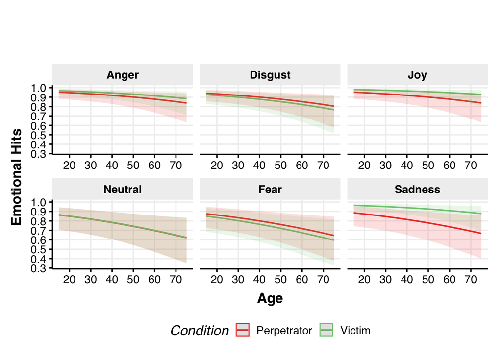

```r
plotemocov = ggpredict(emocov, terms = c("age", "condition", "newemo"), ci_level = 0.95) %>%
  plot() +
  labs(x = "Age", y = "Emotional Hits", colour = "Condition", title = "", element_text(size = 14)) +
  scale_fill_Publication() +
  scale_colour_Publication() +
  theme_Publication() +
  scale_x_continuous(breaks = c(20, 30, 40, 50, 60, 70)) +
  scale_y_continuous(breaks = c(0.3, 0.4, 0.5, 0.6, 0.7, 0.8, 0.9, 1))

plotemocov
```

## 2. Study 2

### a) Reaction Time

#### Full mixed-effect model

```r
full2 = lmer(log(rt_net) ~ condition * newemo * scenarios + (1|number_ID) + (1|item),
             na.action = na.omit,
             data = data2)
```

Summary

```r
tbl_regression(full2,
               label = list(condition ~ "Condition",
                            newemo ~ "Emotion",
                            scenarios ~ "Scenario")) %>%
  modify_column_unhide(column = std.error) %>%
  modify_column_unhide(column = statistic) %>%
  modify_header(label = "**Variable**") %>%
  bold_p() %>%
  modify_fmt_fun(statistic ~ style_sigfig) %>%
  add_significance_stars(hide_ci = FALSE,
                         hide_p = FALSE,
                         pattern = "{p.value}{stars}") %>%
  add_glance_source_note(label = list(sigma ~ "\U03C3"),
                         include = c(AIC, sigma))
```

| **Variable** | **Beta** | **SE**<sup>1</sup> | **Statistic** | **95% CI**<sup>1</sup> | **p-value**<sup>2</sup> |
| --- | --- | --- | --- | --- | --- |
| Condition |  |  |  |  |  |
| Perpetrator | — | — | — | — |  |
| Victim | -0.05 | 0.045 | -1.2 | -0.14, 0.03 | 0.2 |
| Emotion |  |  |  |  |  |
| Anger | — | — | — | — |  |
| Disgust | 0.04 | 0.017 | 2.4 | 0.01, 0.08 | 0.016* |
| Neutral | 0.12 | 0.018 | 7.1 | 0.09, 0.16 | <0.001*** |
| Sadness | 0.02 | 0.017 | 0.95 | -0.02, 0.05 | 0.3 |
| Scenario |  |  |  |  |  |
| Transgression | — | — | — | — |  |
| Control | -0.03 | 0.024 | -1.2 | -0.08, 0.02 | 0.3 |
| Condition * Emotion |  |  |  |  |  |
| Victim * Disgust | 0.00 | 0.025 | 0.00 | -0.05, 0.05 | >0.9 |
| Victim * Neutral | -0.03 | 0.025 | -1.0 | -0.08, 0.02 | 0.3 |
| Victim * Sadness | -0.06 | 0.025 | -2.5 | -0.11, -0.01 | 0.013* |
| Condition * Scenario |  |  |  |  |  |
| Victim * Control | 0.01 | 0.026 | 0.56 | -0.04, 0.07 | 0.6 |
| Emotion * Scenario |  |  |  |  |  |
| Disgust * Control | -0.06 | 0.026 | -2.1 | -0.11, 0.00 | 0.032* |
| Neutral * Control | -0.08 | 0.026 | -3.3 | -0.14, -0.03 | 0.001** |
| Sadness * Control | -0.02 | 0.026 | -0.67 | -0.07, 0.03 | 0.5 |
| Condition * Emotion * Scenario |  |  |  |  |  |
| Victim * Disgust * Control | 0.02 | 0.037 | 0.55 | -0.05, 0.09 | 0.6 |
| Victim * Neutral * Control | 0.03 | 0.037 | 0.84 | -0.04, 0.10 | 0.4 |
| Victim * Sadness * Control | 0.07 | 0.037 | 2.0 | 0.00, 0.15 | 0.043* |

AIC = 8,926; σ = 0.348  
<sup>1</sup> SE = Standard Error, CI = Confidence Interval  
<sup>2</sup> *p<0.05; **p<0.01; ***p<0.001

Conditional and marginal coefficient of determination

```r
Anova(full2, type = 3)
```

```
## Analysis of Deviance Table (Type III Wald chisquare tests)
##
## Response: log(rt_net)
##                                 Chisq Df Pr(>Chisq)
## (Intercept)                45844.7212  1  < 2.2e-16 ***
## condition                      1.4129  1   0.234581
## newemo                        58.0326  3  1.547e-12 ***
## scenarios                      1.3310  1   0.248629
## condition:newemo               8.2634  3   0.040871 *
## condition:scenarios            0.3112  1   0.576938
## newemo:scenarios              13.0046  3   0.004627 **
## condition:newemo:scenarios     4.3598  3   0.225146
## ---
## Signif. codes:  0 '***' 0.001 '**' 0.01 '*' 0.05 '.' 0.1 ' ' 1
```

```r
round(r.squaredGLMM(full2, method = "marginal"), 4)
```

```
##         R2m   R2c
## [1,] 0.0155 0.339
```

- Main effect of *Emotion*
  $$\chi^2(3)
  = 58.033, p < .001$$
- Interaction of *Condition* and *Emotion*
  $$\chi^2(3) = 8.263, p = .041$$
- Interaction of *Emotion* and *Scenario*
  $$\chi^2(3) = 13.005, p = .005$$

Variance explained by the model:
$$R^2_m =
1.55\% \text{ (fixed)}$$
$$R^2_c =
33.90\% \text{ (fixed + random)}$$

#### Pairwise comparisons & estimated marginal means

```r
emmeans(full2, pairwise ~ newemo, lmer.df = "asymp", type = "response", adjust = "bonferroni")
```

```
## $emmeans
##  newemo  response   SE  df asymp.LCL asymp.UCL
##  Anger       1043 23.8 Inf       998      1091
##  Disgust     1064 24.3 Inf      1017      1112
##  Neutral     1126 25.7 Inf      1077      1178
##  Sadness     1039 23.7 Inf       993      1086
##
## Results are averaged over the levels of: condition, scenarios
## Degrees-of-freedom method: asymptotic
## Confidence level used: 0.95
## Intervals are back-transformed from the log scale
##
## $contrasts
##  contrast          ratio      SE  df null z.ratio p.value
##  Anger / Disgust   0.981 0.00908 Inf    1  -2.094  0.2176
##  Anger / Neutral   0.926 0.00863 Inf    1  -8.213  <.0001
##  Anger / Sadness   1.004 0.00927 Inf    1   0.482  1.0000
##  Disgust / Neutral 0.944 0.00883 Inf    1  -6.113  <.0001
##  Disgust / Sadness 1.024 0.00949 Inf    1   2.572  0.0607
##  Neutral / Sadness 1.084 0.01012 Inf    1   8.680  <.0001
##
## Results are averaged over the levels of: condition, scenarios
## Degrees-of-freedom method: asymptotic
## P value adjustment: bonferroni method for 6 tests
## Tests are performed on the log scale
```

```r
emmeans(full2, pairwise ~ scenarios, lmer.df = "asymp", type = "response", adjust = "bonferroni")
```

```
## $emmeans
##  scenarios     response   SE  df asymp.LCL asymp.UCL
##  Transgression     1091 25.5 Inf      1042      1142
##  Control           1044 25.0 Inf       996      1094
##
## Results are averaged over the levels of: condition, newemo
## Degrees-of-freedom method: asymptotic
## Confidence level used: 0.95
## Intervals are back-transformed from the log scale
##
## $contrasts
##  contrast                ratio     SE  df null z.ratio p.value
##  Transgression / Control  1.04 0.0176 Inf    1   2.598  0.0094
##
## Results are averaged over the levels of: condition, newemo
## Degrees-of-freedom method: asymptotic
## Tests are performed on the log scale
```

```r
emmeans(full2, pairwise ~ newemo|condition, lmer.df = "asymp", type = "response", adjust = "bonferroni")
```

```
## $emmeans
## condition = Perpetrator:
##  newemo  response   SE  df asymp.LCL asymp.UCL
##  Anger       1067 32.9 Inf      1005      1134
##  Disgust     1083 33.4 Inf      1019      1150
##  Neutral     1158 35.7 Inf      1090      1230
##  Sadness     1076 33.2 Inf      1013      1143
##
## condition = Victim:
##  newemo  response   SE  df asymp.LCL asymp.UCL
##  Anger       1020 32.5 Inf       958      1085
##  Disgust     1045 33.3 Inf       982      1112
##  Neutral     1095 34.9 Inf      1029      1166
##  Sadness     1003 31.9 Inf       942      1067
##
## Results are averaged over the levels of: scenarios
## Degrees-of-freedom method: asymptotic
## Confidence level used: 0.95
## Intervals are back-transformed from the log scale
##
## $contrasts
## condition = Perpetrator:
##  contrast          ratio     SE  df null z.ratio p.value
##  Anger / Disgust   0.986 0.0127 Inf    1  -1.115  1.0000
##  Anger / Neutral   0.922 0.0119 Inf    1  -6.308  <.0001
##  Anger / Sadness   0.992 0.0128 Inf    1  -0.620  1.0000
##  Disgust / Neutral 0.935 0.0121 Inf    1  -5.183  <.0001
##  Disgust / Sadness 1.006 0.0130 Inf    1   0.493  1.0000
##  Neutral / Sadness 1.077 0.0140 Inf    1   5.671  <.0001
##
## condition = Victim:
##  contrast          ratio     SE  df null z.ratio p.value
##  Anger / Disgust   0.976 0.0130 Inf    1  -1.835  0.3991
##  Anger / Neutral   0.931 0.0125 Inf    1  -5.326  <.0001
##  Anger / Sadness   1.017 0.0135 Inf    1   1.275  1.0000
##  Disgust / Neutral 0.954 0.0128 Inf    1  -3.492  0.0029
##  Disgust / Sadness 1.042 0.0138 Inf    1   3.107  0.0113
##  Neutral / Sadness 1.092 0.0146 Inf    1   6.592  <.0001
##
## Results are averaged over the levels of: scenarios
## Degrees-of-freedom method: asymptotic
## P value adjustment: bonferroni method for 6 tests
## Tests are performed on the log scale
```

```r
emmeans(full2, pairwise ~ newemo|scenarios, lmer.df = "asymp", type = "response", adjust = "bonferroni")
```

```
## $emmeans
## scenarios = Transgression:
##  newemo  response   SE  df asymp.LCL asymp.UCL
##  Anger       1054 25.9 Inf      1004      1106
##  Disgust     1099 27.1 Inf      1047      1153
##  Neutral     1178 29.1 Inf      1122      1236
##  Sadness     1039 25.6 Inf       990      1090
##
## scenarios = Control:
##  newemo  response   SE  df asymp.LCL asymp.UCL
##  Anger       1033 26.2 Inf       983      1085
##  Disgust     1029 26.1 Inf       979      1082
##  Neutral     1077 27.4 Inf      1025      1132
##  Sadness     1039 26.3 Inf       988      1091
##
## Results are averaged over the levels of: condition
## Degrees-of-freedom method: asymptotic
## Confidence level used: 0.95
## Intervals are back-transformed from the log scale
##
## $contrasts
## scenarios = Transgression:
##  contrast          ratio     SE  df null z.ratio p.value
##  Anger / Disgust   0.959 0.0120 Inf    1  -3.351  0.0048
##  Anger / Neutral   0.895 0.0113 Inf    1  -8.809  <.0001
##  Anger / Sadness   1.015 0.0127 Inf    1   1.163  1.0000
##  Disgust / Neutral 0.933 0.0118 Inf    1  -5.463  <.0001
##  Disgust / Sadness 1.058 0.0133 Inf    1   4.501  <.0001
##  Neutral / Sadness 1.134 0.0143 Inf    1   9.935  <.0001
##
## scenarios = Control:
##  contrast          ratio     SE  df null z.ratio p.value
##  Anger / Disgust   1.003 0.0137 Inf    1   0.234  1.0000
##  Anger / Neutral   0.959 0.0132 Inf    1  -3.057  0.0134
##  Anger / Sadness   0.994 0.0135 Inf    1  -0.414  1.0000
##  Disgust / Neutral 0.956 0.0132 Inf    1  -3.280  0.0062
##  Disgust / Sadness 0.991 0.0135 Inf    1  -0.646  1.0000
##  Neutral / Sadness 1.037 0.0142 Inf    1   2.647  0.0487
##
## Results are averaged over the levels of: condition
## Degrees-of-freedom method: asymptotic
## P value adjustment: bonferroni method for 6 tests
## Tests are performed on the log scale
```

```r
emmeans(full2, pairwise ~ scenarios|newemo, lmer.df = "asymp", type = "response", adjust = "bonferroni")
```

```
## $emmeans
## newemo = Anger:
##  scenarios     response   SE  df asymp.LCL asymp.UCL
##  Transgression     1054 25.9 Inf      1004      1106
##  Control           1033 26.2 Inf       983      1085
##
## newemo = Disgust:
##  scenarios     response   SE  df asymp.LCL asymp.UCL
##  Transgression     1099 27.1 Inf      1047      1153
##  Control           1029 26.1 Inf       979      1082
##
## newemo = Neutral:
##  scenarios     response   SE  df asymp.LCL asymp.UCL
##  Transgression     1178 29.1 Inf      1122      1236
##  Control           1077 27.4 Inf      1025      1132
##
## newemo = Sadness:
##  scenarios     response   SE  df asymp.LCL asymp.UCL
##  Transgression     1039 25.6 Inf       990      1090
##  Control           1039 26.3 Inf       988      1091
##
## Results are averaged over the levels of: condition
## Degrees-of-freedom method: asymptotic
## Confidence level used: 0.95
## Intervals are back-transformed from the log scale
##
## $contrasts
## newemo = Anger:
##  contrast                ratio     SE  df null z.ratio p.value
##  Transgression / Control  1.02 0.0207 Inf    1   0.999  0.3176
##
## newemo = Disgust:
##  contrast                ratio     SE  df null z.ratio p.value
##  Transgression / Control  1.07 0.0217 Inf    1   3.216  0.0013
##
## newemo = Neutral:
##  contrast                ratio     SE  df null z.ratio p.value
##  Transgression / Control  1.09 0.0224 Inf    1   4.373  <.0001
##
## newemo = Sadness:
##  contrast                ratio     SE  df null z.ratio p.value
##  Transgression / Control  1.00 0.0203 Inf    1   0.005  0.9957
##
## Results are averaged over the levels of: condition
## Degrees-of-freedom method: asymptotic
## Tests are performed on the log scale
```

#### Plot all interaction effects

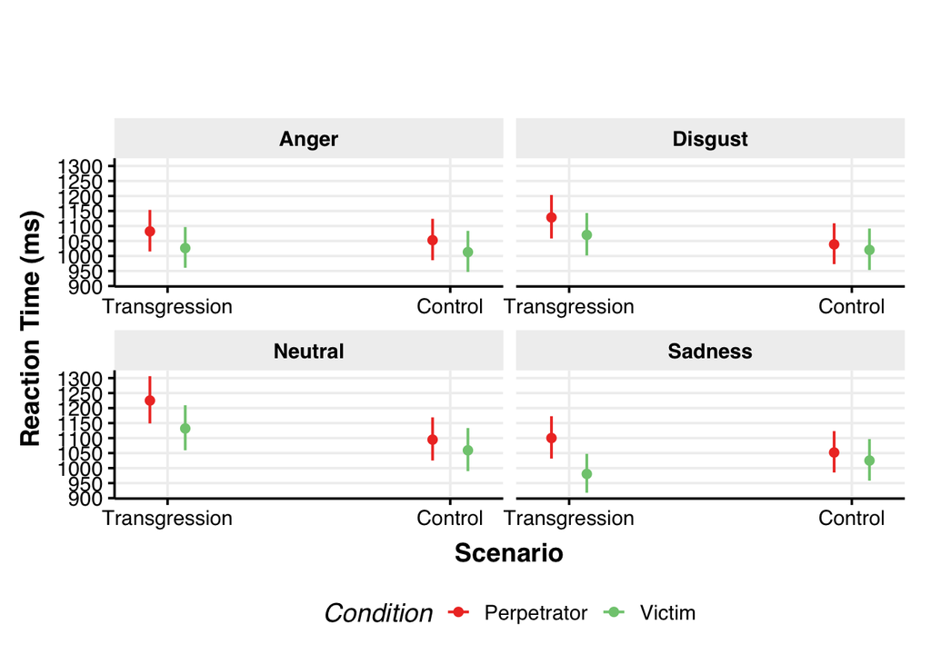

```r
plotfull2 = ggpredict(full2, terms = c("scenarios", "condition", "newemo"), ci_level = 0.95) %>%
  plot() +
  labs(x = "Scenario", y = "Reaction Time (ms)", colour = "Condition", title = "", element_text(size = 14)) +
  scale_fill_Publication() +
  scale_colour_Publication() +
  theme_Publication() +
  scale_y_continuous(breaks = c(800, 850, 900, 950, 1000, 1050, 1100, 1150, 1200, 1250, 1300, 1350, 1400))

plotfull2
```

### b) Emotional Hits

#### Full generalized mixed-effect model

```r
emo2 = glmer(score ~ scenarios * newemo * condition + (1|number_ID) + (1|item),
             data = data2,
             family = binomial,
             control = glmerControl(optimizer = "bobyqa"))
```

Summary

```r
tbl_regression(emo2,
               label = list(condition ~ "Condition",
                            newemo ~ "Emotion",
                            scenarios ~ "Scenario")) %>%
  modify_column_unhide(column = std.error) %>%
  modify_column_unhide(column = statistic) %>%
  modify_header(label = "**Variable**") %>%
  bold_p() %>%
  modify_fmt_fun(statistic ~ style_sigfig) %>%
  add_significance_stars(hide_ci = FALSE,
                         hide_p = FALSE,
                         pattern = "{p.value}{stars}") %>%
  add_glance_source_note(label = list(sigma ~ "\U03C3"),
                         include = c(AIC, sigma))
```

| **Variable** | **log(OR)**<sup>1</sup> | **SE**<sup>1</sup> | **Statistic** | **95% CI**<sup>1</sup> | **p-value**<sup>2</sup> |
| --- | --- | --- | --- | --- | --- |
| Scenario |  |  |  |  |  |
| Transgression | — | — | — | — |  |
| Control | 0.28 | 0.187 | 1.5 | -0.09, 0.65 | 0.14 |
| Emotion |  |  |  |  |  |
| Anger | — | — | — | — |  |
| Disgust | -0.27 | 0.132 | -2.1 | -0.53, -0.01 | 0.039* |
| Neutral | -0.36 | 0.131 | -2.8 | -0.62, -0.11 | 0.006** |
| Sadness | -0.67 | 0.128 | -5.3 | -0.92, -0.42 | <0.001*** |
| Condition |  |  |  |  |  |
| Perpetrator | — | — | — | — |  |
| Victim | 0.39 | 0.258 | 1.5 | -0.11, 0.90 | 0.13 |
| Scenario * Emotion |  |  |  |  |  |
| Control * Disgust | 0.50 | 0.210 | 2.4 | 0.09, 0.92 | 0.017* |
| Control * Neutral | -0.44 | 0.196 | -2.3 | -0.83, -0.06 | 0.024* |
| Control * Sadness | 0.78 | 0.206 | 3.8 | 0.37, 1.2 | <0.001*** |
| Scenario * Condition |  |  |  |  |  |
| Control * Victim | -0.40 | 0.218 | -1.8 | -0.83, 0.03 | 0.066 |
| Emotion * Condition |  |  |  |  |  |
| Disgust * Victim | -0.15 | 0.198 | -0.76 | -0.54, 0.24 | 0.4 |
| Neutral * Victim | -0.01 | 0.198 | -0.05 | -0.40, 0.38 | >0.9 |
| Sadness * Victim | 0.75 | 0.203 | 3.7 | 0.35, 1.1 | <0.001*** |
| Scenario * Emotion * Condition |  |  |  |  |  |
| Control * Disgust * Victim | -0.05 | 0.306 | -0.17 | -0.65, 0.55 | 0.9 |
| Control * Neutral * Victim | 0.07 | 0.290 | 0.24 | -0.50, 0.64 | 0.8 |
| Control * Sadness * Victim | -0.77 | 0.308 | -2.5 | -1.4, -0.16 | 0.013* |

AIC = 10,056; σ = 1.00  
<sup>1</sup> OR = Odds Ratio, SE = Standard Error, CI = Confidence Interval  
<sup>2</sup> *p<0.05; **p<0.01; ***p<0.001

Anova & conditional and marginal coefficient of determination

```r
Anova(emo2, type = 3)
```

```
## Analysis of Deviance Table (Type III Wald chisquare tests)
##
## Response: score
##                              Chisq Df Pr(>Chisq)
## (Intercept)                78.9617  1  < 2.2e-16 ***
## scenarios                   2.2337  1    0.13503
## newemo                     28.6628  3  2.636e-06 ***
## condition                   2.3391  1    0.12616
## scenarios:newemo           46.5670  3  4.297e-10 ***
## scenarios:condition         3.3893  1    0.06562 .
## newemo:condition           25.5658  3  1.176e-05 ***
## scenarios:newemo:condition 10.0042  3    0.01853 *
## ---
## Signif. codes:  0 '***' 0.001 '**' 0.01 '*' 0.05 '.' 0.1 ' ' 1
```

```r
round(r.squaredGLMM(emo2, method = "marginal"), 4)
```

```
##                R2m    R2c
## theoretical 0.0285 0.3472
## delta       0.0186 0.2264
```

- Main effect of *Emotion*
  $$\chi^2(3)
  = 28.663, p < .001$$
- Interaction between *Emotion* and *Scenario*
  $$\chi^2(3) = 46.567, p < .001$$
- Interaction between *Emotion* and *Condition*
  $$\chi^2(3) = 25.566, p < .001$$
- Interaction between *Emotion*, *Condition* and *Scenario*
  $$\chi^2(3) = 10.004, p =
  .019$$

Variance explained by the model:
$$R^2_m =
1.86\% \text{ (fixed)}$$
$$R^2_c =
22.64\% \text{ (fixed + random)}$$

#### Pairwise comparisons (estimated marginal means and pairwise comparisons)

```r
emmeans(emo2, pairwise ~ newemo, lmer.df = "asymp", type = "response", adjust = "bonferroni")
```

```
## $emmeans
##  newemo   prob     SE  df asymp.LCL asymp.UCL
##  Anger   0.875 0.0145 Inf     0.843     0.901
##  Disgust 0.862 0.0157 Inf     0.829     0.890
##  Neutral 0.798 0.0209 Inf     0.754     0.836
##  Sadness 0.863 0.0157 Inf     0.830     0.891
##
## Results are averaged over the levels of: scenarios, condition
## Confidence level used: 0.95
## Intervals are back-transformed from the logit scale
##
## $contrasts
##  contrast          odds.ratio     SE  df null z.ratio p.value
##  Anger / Disgust        1.115 0.0853 Inf    1   1.421  0.9321
##  Anger / Neutral        1.771 0.1288 Inf    1   7.857  <.0001
##  Anger / Sadness        1.106 0.0852 Inf    1   1.313  1.0000
##  Disgust / Neutral      1.588 0.1144 Inf    1   6.425  <.0001
##  Disgust / Sadness      0.992 0.0758 Inf    1  -0.099  1.0000
##  Neutral / Sadness      0.625 0.0453 Inf    1  -6.481  <.0001
##
## Results are averaged over the levels of: scenarios, condition
## P value adjustment: bonferroni method for 6 tests
## Tests are performed on the log odds ratio scale
```

```r
emmeans(emo2, pairwise ~ scenarios, lmer.df = "asymp", type = "response", adjust = "bonferroni")
```

```
## $emmeans
##  scenarios      prob     SE  df asymp.LCL asymp.UCL
##  Transgression 0.839 0.0183 Inf     0.800     0.872
##  Control       0.864 0.0167 Inf     0.827     0.893
##
## Results are averaged over the levels of: newemo, condition
## Confidence level used: 0.95
## Intervals are back-transformed from the logit scale
##
## $contrasts
##  contrast                odds.ratio    SE  df null z.ratio p.value
##  Transgression / Control      0.824 0.104 Inf    1  -1.539  0.1238
##
## Results are averaged over the levels of: newemo, condition
## Tests are performed on the log odds ratio scale
```

```r
emmeans(emo2, pairwise ~ newemo|scenarios, lmer.df = "asymp", type = "response", adjust = "bonferroni")
```

```
## $emmeans
## scenarios = Transgression:
##  newemo   prob     SE  df asymp.LCL asymp.UCL
##  Anger   0.870 0.0170 Inf     0.833     0.900
##  Disgust 0.826 0.0212 Inf     0.780     0.864
##  Neutral 0.823 0.0215 Inf     0.777     0.861
##  Sadness 0.833 0.0207 Inf     0.788     0.870
##
## scenarios = Control:
##  newemo   prob     SE  df asymp.LCL asymp.UCL
##  Anger   0.879 0.0168 Inf     0.842     0.908
##  Disgust 0.892 0.0154 Inf     0.858     0.919
##  Neutral 0.770 0.0269 Inf     0.713     0.818
##  Sadness 0.889 0.0158 Inf     0.854     0.916
##
## Results are averaged over the levels of: condition
## Confidence level used: 0.95
## Intervals are back-transformed from the logit scale
##
## $contrasts
## scenarios = Transgression:
##  contrast          odds.ratio     SE  df null z.ratio p.value
##  Anger / Disgust        1.415 0.1404 Inf    1   3.504  0.0028
##  Anger / Neutral        1.443 0.1430 Inf    1   3.701  0.0013
##  Anger / Sadness        1.347 0.1364 Inf    1   2.942  0.0196
##  Disgust / Neutral      1.020 0.0966 Inf    1   0.204  1.0000
##  Disgust / Sadness      0.952 0.0924 Inf    1  -0.510  1.0000
##  Neutral / Sadness      0.933 0.0906 Inf    1  -0.710  1.0000
##
## scenarios = Control:
##  contrast          odds.ratio     SE  df null z.ratio p.value
##  Anger / Disgust        0.878 0.1024 Inf    1  -1.115  1.0000
##  Anger / Neutral        2.173 0.2308 Inf    1   7.306  <.0001
##  Anger / Sadness        0.909 0.1055 Inf    1  -0.824  1.0000
##  Disgust / Neutral      2.474 0.2684 Inf    1   8.353  <.0001
##  Disgust / Sadness      1.035 0.1221 Inf    1   0.291  1.0000
##  Neutral / Sadness      0.418 0.0451 Inf    1  -8.083  <.0001
##
## Results are averaged over the levels of: condition
## P value adjustment: bonferroni method for 6 tests
## Tests are performed on the log odds ratio scale
```

```r
emmeans(emo2, pairwise ~ scenarios|newemo, lmer.df = "asymp", type = "response", adjust = "bonferroni")
```

```
## $emmeans
## newemo = Anger:
##  scenarios      prob     SE  df asymp.LCL asymp.UCL
##  Transgression 0.870 0.0170 Inf     0.833     0.900
##  Control       0.879 0.0168 Inf     0.842     0.908
##
## newemo = Disgust:
##  scenarios      prob     SE  df asymp.LCL asymp.UCL
##  Transgression 0.826 0.0212 Inf     0.780     0.864
##  Control       0.892 0.0154 Inf     0.858     0.919
##
## newemo = Neutral:
##  scenarios      prob     SE  df asymp.LCL asymp.UCL
##  Transgression 0.823 0.0215 Inf     0.777     0.861
##  Control       0.770 0.0269 Inf     0.713     0.818
##
## newemo = Sadness:
##  scenarios      prob     SE  df asymp.LCL asymp.UCL
##  Transgression 0.833 0.0207 Inf     0.788     0.870
##  Control       0.889 0.0158 Inf     0.854     0.916
##
## Results are averaged over the levels of: condition
## Confidence level used: 0.95
## Intervals are back-transformed from the logit scale
##
## $contrasts
## newemo = Anger:
##  contrast                odds.ratio     SE  df null z.ratio p.value
##  Transgression / Control      0.925 0.1461 Inf    1  -0.496  0.6200
##
## newemo = Disgust:
##  contrast                odds.ratio     SE  df null z.ratio p.value
##  Transgression / Control      0.574 0.0900 Inf    1  -3.541  0.0004
##
## newemo = Neutral:
##  contrast                odds.ratio     SE  df null z.ratio p.value
##  Transgression / Control      1.392 0.2075 Inf    1   2.220  0.0265
##
## newemo = Sadness:
##  contrast                odds.ratio     SE  df null z.ratio p.value
##  Transgression / Control      0.624 0.0985 Inf    1  -2.989  0.0028
##
## Results are averaged over the levels of: condition
## Tests are performed on the log odds ratio scale
```

```r
emmeans(emo2, pairwise ~ newemo|condition, lmer.df = "asymp", type = "response", adjust = "bonferroni")
```

```
## $emmeans
## condition = Perpetrator:
##  newemo   prob     SE  df asymp.LCL asymp.UCL
##  Anger   0.864 0.0206 Inf     0.818     0.899
##  Disgust 0.861 0.0209 Inf     0.815     0.897
##  Neutral 0.780 0.0293 Inf     0.717     0.832
##  Sadness 0.827 0.0248 Inf     0.773     0.870
##
## condition = Victim:
##  newemo   prob     SE  df asymp.LCL asymp.UCL
##  Anger   0.885 0.0186 Inf     0.843     0.917
##  Disgust 0.863 0.0213 Inf     0.816     0.900
##  Neutral 0.815 0.0268 Inf     0.756     0.862
##  Sadness 0.893 0.0175 Inf     0.853     0.923
##
## Results are averaged over the levels of: scenarios
## Confidence level used: 0.95
## Intervals are back-transformed from the logit scale
##
## $contrasts
## condition = Perpetrator:
##  contrast          odds.ratio     SE  df null z.ratio p.value
##  Anger / Disgust        1.020 0.1073 Inf    1   0.193  1.0000
##  Anger / Neutral        1.793 0.1765 Inf    1   5.932  <.0001
##  Anger / Sadness        1.327 0.1364 Inf    1   2.756  0.0352
##  Disgust / Neutral      1.757 0.1743 Inf    1   5.681  <.0001
##  Disgust / Sadness      1.301 0.1346 Inf    1   2.540  0.0665
##  Neutral / Sadness      0.740 0.0714 Inf    1  -3.119  0.0109
##
## condition = Victim:
##  contrast          odds.ratio     SE  df null z.ratio p.value
##  Anger / Disgust        1.218 0.1355 Inf    1   1.773  0.4576
##  Anger / Neutral        1.749 0.1872 Inf    1   5.222  <.0001
##  Anger / Sadness        0.922 0.1058 Inf    1  -0.704  1.0000
##  Disgust / Neutral      1.436 0.1499 Inf    1   3.465  0.0032
##  Disgust / Sadness      0.757 0.0852 Inf    1  -2.471  0.0809
##  Neutral / Sadness      0.527 0.0572 Inf    1  -5.900  <.0001
##
## Results are averaged over the levels of: scenarios
## P value adjustment: bonferroni method for 6 tests
## Tests are performed on the log odds ratio scale
```

```r
emmeans(emo2, pairwise ~ scenarios*condition*newemo, type = "response", adjust = "bonferroni")
```

```
## $emmeans
##  scenarios     condition   newemo   prob     SE  df asymp.LCL asymp.UCL
##  Transgression Perpetrator Anger   0.846 0.0250 Inf     0.791     0.889
##  Control       Perpetrator Anger   0.879 0.0216 Inf     0.830     0.916
##  Transgression Victim      Anger   0.891 0.0198 Inf     0.846     0.924
##  Control       Victim      Anger   0.879 0.0224 Inf     0.827     0.916
##  Transgression Perpetrator Disgust 0.808 0.0294 Inf     0.743     0.859
##  Control       Perpetrator Disgust 0.902 0.0184 Inf     0.859     0.933
##  Transgression Victim      Disgust 0.843 0.0262 Inf     0.784     0.888
##  Control       Victim      Disgust 0.882 0.0220 Inf     0.831     0.918
##  Transgression Perpetrator Neutral 0.793 0.0309 Inf     0.726     0.847
##  Control       Perpetrator Neutral 0.765 0.0349 Inf     0.690     0.826
##  Transgression Victim      Neutral 0.849 0.0254 Inf     0.793     0.893
##  Control       Victim      Neutral 0.774 0.0350 Inf     0.699     0.836
##  Transgression Perpetrator Sadness 0.738 0.0360 Inf     0.662     0.802
##  Control       Perpetrator Sadness 0.890 0.0201 Inf     0.844     0.924
##  Transgression Victim      Sadness 0.898 0.0188 Inf     0.855     0.930
##  Control       Victim      Sadness 0.887 0.0212 Inf     0.839     0.923
##
## Confidence level used: 0.95
## Intervals are back-transformed from the logit scale
##
## $contrasts
##  contrast
##  Transgression Perpetrator Anger / Control Perpetrator Anger
##  Transgression Perpetrator Anger / Transgression Victim Anger
##  Transgression Perpetrator Anger / Control Victim Anger
##  Transgression Perpetrator Anger / Transgression Perpetrator Disgust
##  Transgression Perpetrator Anger / Control Perpetrator Disgust
##  Transgression Perpetrator Anger / Transgression Victim Disgust
##  Transgression Perpetrator Anger / Control Victim Disgust
##  Transgression Perpetrator Anger / Transgression Perpetrator Neutral
##  Transgression Perpetrator Anger / Control Perpetrator Neutral
##  Transgression Perpetrator Anger / Transgression Victim Neutral
##  Transgression Perpetrator Anger / Control Victim Neutral
##  Transgression Perpetrator Anger / Transgression Perpetrator Sadness
##  Transgression Perpetrator Anger / Control Perpetrator Sadness
##  Transgression Perpetrator Anger / Transgression Victim Sadness
##  Transgression Perpetrator Anger / Control Victim Sadness
##  Control Perpetrator Anger / Transgression Victim Anger
```

[output cut: 213 more lines]

```
##       0.639 0.0963 Inf    1  -2.969  0.3585
##       0.715 0.1384 Inf    1  -1.731  1.0000
##       1.218 0.3331 Inf    1   0.723  1.0000
##       0.424 0.1106 Inf    1  -3.289  0.1205
##       0.389 0.0734 Inf    1  -5.005  0.0001
##       0.435 0.0676 Inf    1  -5.353  <.0001
##       0.348 0.0638 Inf    1  -5.762  <.0001
##       0.319 0.0812 Inf    1  -4.486  0.0009
##       0.357 0.1007 Inf    1  -3.652  0.0312
##       0.918 0.2667 Inf    1  -0.295  1.0000
##       1.027 0.2774 Inf    1   0.100  1.0000
##       1.119 0.2237 Inf    1   0.563  1.0000
##
## P value adjustment: bonferroni method for 120 tests
## Tests are performed on the log odds ratio scale
```

#### Plot all interaction effects

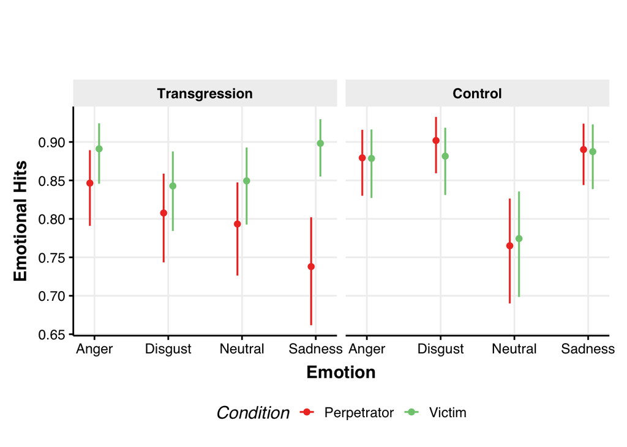

```r
plotemo2 = ggpredict(emo2, terms = c("newemo", "condition", "scenarios"), ci_level = 0.95) %>%
  plot() +
  labs(x = "Emotion", y = "Emotional Hits", colour = "Condition", title = "", element_text(size = 14)) +
  scale_fill_Publication() +
  scale_colour_Publication() +
  theme_Publication() +
  scale_y_continuous(breaks = c(0.6, 0.65, 0.7, 0.75, 0.8, 0.85, 0.9, 0.95, 1))

plotemo2
```

### c) Exploratory Analyses

Preparation

```r
subdata = data2 %>%
  filter(newclass %in% c("Harm", "Injustice", "Humiliation"))
```

#### RT with Condition and Class (preregistered)

```r
exprt2 = lmer(log(rt_net) ~ condition * newclass + (1|number_ID) + (1|item),
              na.action = na.omit,
              data = subdata)
```

Summary

```r
tbl_regression(exprt2,
               label = list(condition ~ "Condition",
                            newclass ~ "Class of Transgression")) %>%
  modify_column_unhide(column = std.error) %>%
  modify_column_unhide(column = statistic) %>%
  modify_header(label = "**Variable**") %>%
  bold_p() %>%
  modify_fmt_fun(statistic ~ style_sigfig) %>%
  add_significance_stars(hide_ci = FALSE,
                         hide_p = FALSE,
                         pattern = "{p.value}{stars}") %>%
  add_glance_source_note(label = list(sigma ~ "\U03C3"),
                         include = c(AIC, sigma))
```

| **Variable** | **Beta** | **SE**<sup>1</sup> | **Statistic** | **95% CI**<sup>1</sup> | **p-value**<sup>2</sup> |
| --- | --- | --- | --- | --- | --- |
| Condition |  |  |  |  |  |
| Perpetrator | — | — | — | — |  |
| Victim | -0.06 | 0.045 | -1.3 | -0.15, 0.03 | 0.2 |
| Class of Transgression |  |  |  |  |  |
| Harm | — | — | — | — |  |
| Humiliation | 0.07 | 0.023 | 3.0 | 0.02, 0.12 | 0.009** |
| Injustice | 0.07 | 0.023 | 2.8 | 0.02, 0.12 | 0.013* |
| Condition * Class of Transgression |  |  |  |  |  |
| Victim * Humiliation | -0.02 | 0.022 | -0.98 | -0.06, 0.02 | 0.3 |
| Victim * Injustice | -0.03 | 0.022 | -1.4 | -0.07, 0.01 | 0.2 |

AIC = 5,050; σ = 0.351  
<sup>1</sup> SE = Standard Error, CI = Confidence Interval  
<sup>2</sup> *p<0.05; **p<0.01; ***p<0.001

Anova & conditional and marginal coefficient of determination

```r
Anova(exprt2, type = 3)
```

```
## Analysis of Deviance Table (Type III Wald chisquare tests)
##
## Response: log(rt_net)
##                         Chisq Df Pr(>Chisq)
## (Intercept)        42941.9346  1  < 2.2e-16 ***
## condition              1.6470  1   0.199367
## newclass              11.3810  2   0.003378 **
## condition:newclass     2.1641  2   0.338897
## ---
## Signif. codes:  0 '***' 0.001 '**' 0.01 '*' 0.05 '.' 0.1 ' ' 1
```

```r
round(r.squaredGLMM(exprt2, method = "marginal"), 4)
```

```
##         R2m    R2c
## [1,] 0.0115 0.3458
```

- Main effect of *Class*
  $$\chi^2(2) =
  11.381, p = .003$$

Variance explained by the model:
$$R^2_m =
1.15\% \text{ (fixed)}$$
$$R^2_c =
34.58\% \text{ (fixed + random)}$$

Pairwise comparisons & estimated marginal means

```r
emmeans(exprt2, pairwise ~ newclass, lmer.df = "asymp", type = "response", adjust = "bonferroni")
```

```
## $emmeans
##  newclass    response   SE  df asymp.LCL asymp.UCL
##  Harm            1052 27.1 Inf      1000      1106
##  Humiliation     1116 28.8 Inf      1061      1174
##  Injustice       1107 28.6 Inf      1052      1164
##
## Results are averaged over the levels of: condition
## Degrees-of-freedom method: asymptotic
## Confidence level used: 0.95
## Intervals are back-transformed from the log scale
##
## $contrasts
##  contrast                ratio     SE  df null z.ratio p.value
##  Harm / Humiliation      0.942 0.0197 Inf    1  -2.847  0.0132
##  Harm / Injustice        0.950 0.0198 Inf    1  -2.435  0.0447
##  Humiliation / Injustice 1.009 0.0211 Inf    1   0.410  1.0000
##
## Results are averaged over the levels of: condition
## Degrees-of-freedom method: asymptotic
## P value adjustment: bonferroni method for 3 tests
## Tests are performed on the log scale
```

Plot all interaction effects

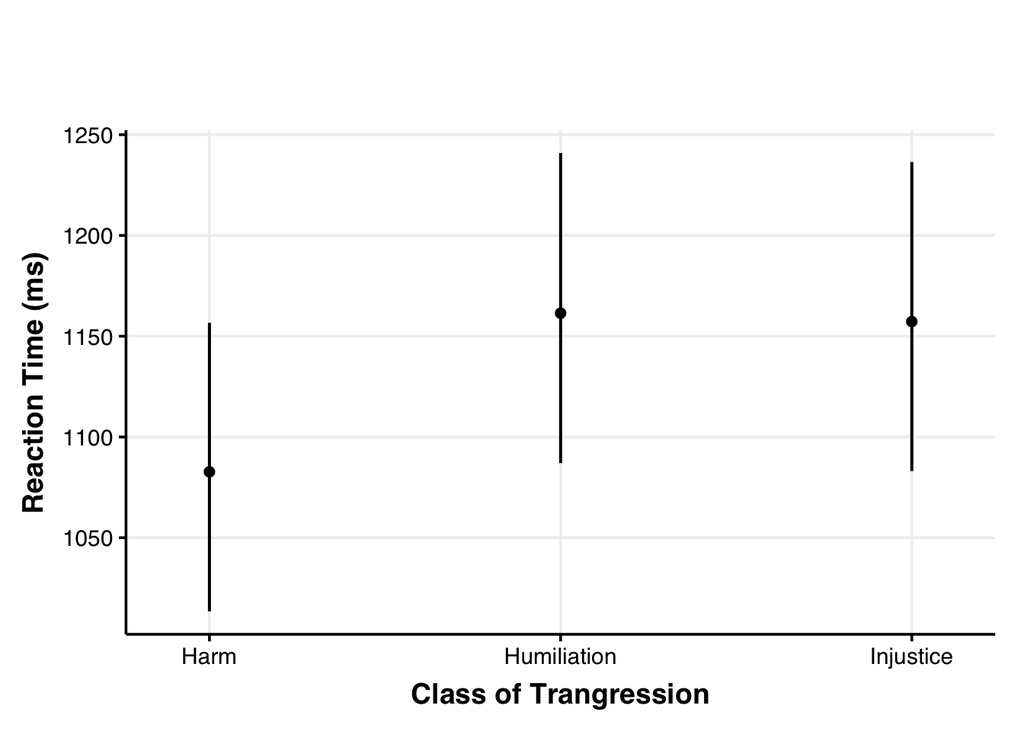

```r
plotexprt2 = ggpredict(exprt2, terms = c("newclass"), ci_level = 0.95) %>%
  plot() +
  labs(x = "Class of Trangression", y = "Reaction Time (ms)", title = "", element_text(size = 14)) +
  scale_fill_Publication() +
  scale_colour_Publication() +
  theme_Publication()

plotexprt2
```

#### Emotional Hits with Condition and Class (preregistered)

```r
exphit2 = glmer(score ~ condition * newclass + (1|number_ID) + (1|item),
             data = subdata,
             family = binomial,
             control = glmerControl(optimizer = "bobyqa"))
```

Summary

```r
tbl_regression(exphit2,
               label = list(condition ~ "Condition",
                            newclass ~ "Class of Transgression")) %>%
  modify_column_unhide(column = std.error) %>%
  modify_column_unhide(column = statistic) %>%
  modify_header(label = "**Variable**") %>%
  bold_p() %>%
  modify_fmt_fun(statistic ~ style_sigfig) %>%
  add_significance_stars(hide_ci = FALSE,
                         hide_p = FALSE,
                         pattern = "{p.value}{stars}") %>%
  add_glance_source_note(label = list(sigma ~ "\U03C3"),
                         include = c(AIC, sigma))
```

| **Variable** | **log(OR)**<sup>1</sup> | **SE**<sup>1</sup> | **Statistic** | **95% CI**<sup>1</sup> | **p-value**<sup>2</sup> |
| --- | --- | --- | --- | --- | --- |
| Condition |  |  |  |  |  |
| Perpetrator | — | — | — | — |  |
| Victim | 0.39 | 0.272 | 1.4 | -0.14, 0.92 | 0.2 |
| Class of Transgression |  |  |  |  |  |
| Harm | — | — | — | — |  |
| Humiliation | -0.62 | 0.135 | -4.6 | -0.89, -0.36 | <0.001*** |
| Injustice | -0.68 | 0.134 | -5.1 | -0.94, -0.42 | <0.001*** |
| Condition * Class of Transgression |  |  |  |  |  |
| Victim * Humiliation | 0.10 | 0.173 | 0.56 | -0.24, 0.44 | 0.6 |
| Victim * Injustice | 0.25 | 0.174 | 1.4 | -0.09, 0.59 | 0.2 |

AIC = 5,693; σ = 1.00  
<sup>1</sup> OR = Odds Ratio, SE = Standard Error, CI = Confidence Interval  
<sup>2</sup> *p<0.05; **p<0.01; ***p<0.001

Anova & conditional and marginal coefficient of determination

```r
Anova(exphit2, type = 3)
```

```
## Analysis of Deviance Table (Type III Wald chisquare tests)
##
## Response: score
##                      Chisq Df Pr(>Chisq)
## (Intercept)        98.9428  1  < 2.2e-16 ***
## condition           2.0381  1     0.1534
## newclass           30.5936  2  2.273e-07 ***
## condition:newclass  2.1222  2     0.3461
## ---
## Signif. codes:  0 '***' 0.001 '**' 0.01 '*' 0.05 '.' 0.1 ' ' 1
```

```r
round(r.squaredGLMM(exphit2, method = "marginal"), 4)
```

```
##                R2m    R2c
## theoretical 0.0259 0.3826
## delta       0.0176 0.2598
```

- Main effect of *Class*
  $$\chi^2(2) =
  30.594, p < .001$$

Pairwise comparisons & estimated marginal means

```r
emmeans(exphit2, pairwise ~ newclass, lmer.df = "asymp", type = "response", adjust = "bonferroni")
```

```
## $emmeans
##  newclass     prob     SE  df asymp.LCL asymp.UCL
##  Harm        0.893 0.0140 Inf     0.862     0.917
##  Humiliation 0.824 0.0207 Inf     0.780     0.861
##  Injustice   0.826 0.0204 Inf     0.783     0.863
##
## Results are averaged over the levels of: condition
## Confidence level used: 0.95
## Intervals are back-transformed from the logit scale
##
## $contrasts
##  contrast                odds.ratio    SE  df null z.ratio p.value
##  Harm / Humiliation           1.778 0.202 Inf    1   5.066  <.0001
##  Harm / Injustice             1.745 0.199 Inf    1   4.887  <.0001
##  Humiliation / Injustice      0.981 0.107 Inf    1  -0.174  1.0000
##
## Results are averaged over the levels of: condition
## P value adjustment: bonferroni method for 3 tests
## Tests are performed on the log odds ratio scale
```

Plot all interaction effects

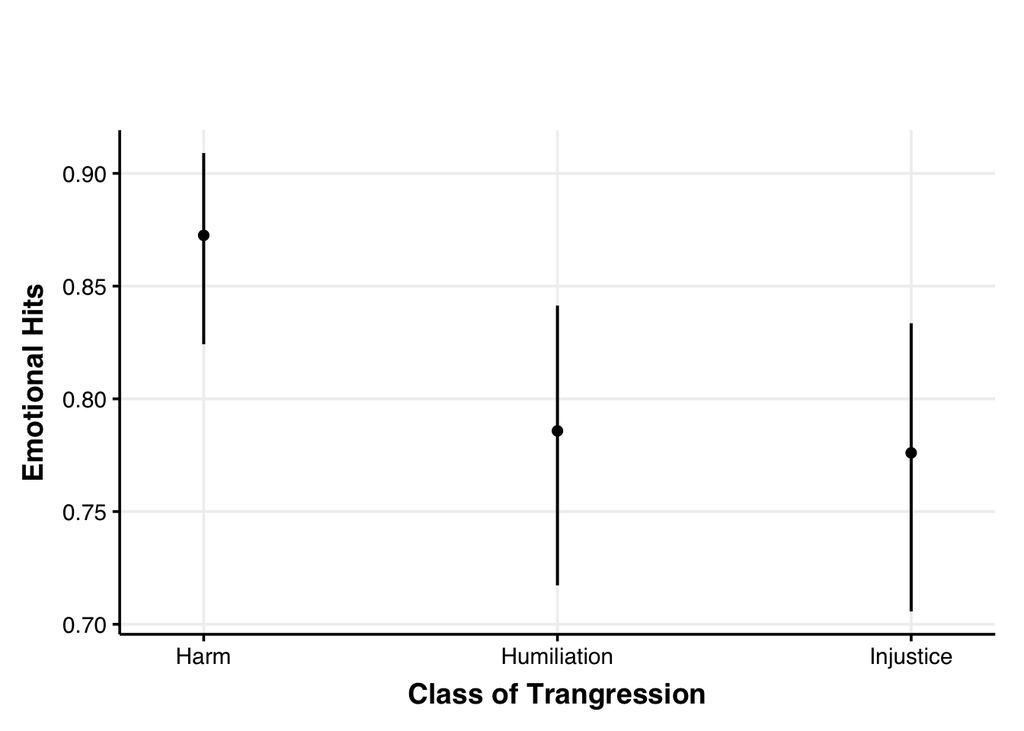

```r
plotexphit2 = ggpredict(exphit2, terms = c("newclass"), ci_level = 0.95) %>%
  plot() +
  labs(x = "Class of Trangression", y = "Emotional Hits", title = "", element_text(size = 14)) +
  scale_fill_Publication() +
  scale_colour_Publication() +
  theme_Publication() +
  scale_y_continuous(breaks = c(0.6, 0.65, 0.7, 0.75, 0.8, 0.85, 0.9, 0.95, 1))

plotexphit2
```

#### RT with Condition, Emotion and Class + covariates (preregistered)

Full mixed-effect model

```r
full2cov = lmer(log(rt_net) ~ condition * newemo * scenarios + age + newgender + political_orientation + (1|number_ID) + (1|item),
           na.action = na.omit,
           data = data2)
```

Summary

```r
tbl_regression(full2cov,
               label = list(condition ~ "Condition",
                            scenarios ~ "Scenarios",
                            newemo ~ "Emotion",
                            age ~ "Age",
                            newgender ~ "Sex",
                            political_orientation ~ "Political Orientation (1-Liberal to 7-Conservative)")) %>%
  modify_column_unhide(column = std.error) %>%
  modify_column_unhide(column = statistic) %>%
  modify_header(label = "**Variable**") %>%
  bold_p() %>%
  modify_fmt_fun(statistic ~ style_sigfig) %>%
  add_significance_stars(hide_ci = FALSE,
                         hide_p = FALSE,
                         pattern = "{p.value}{stars}") %>%
  add_glance_source_note(label = list(sigma ~ "\U03C3"),
                         include = c(AIC, sigma))
```

| **Variable** | **Beta** | **SE**<sup>1</sup> | **Statistic** | **95% CI**<sup>1</sup> | **p-value**<sup>2</sup> |
| --- | --- | --- | --- | --- | --- |
| Condition |  |  |  |  |  |
| Perpetrator | — | — | — | — |  |
| Victim | -0.05 | 0.044 | -1.2 | -0.14, 0.03 | 0.2 |
| Emotion |  |  |  |  |  |
| Anger | — | — | — | — |  |
| Disgust | 0.04 | 0.017 | 2.4 | 0.01, 0.08 | 0.016* |
| Neutral | 0.12 | 0.018 | 7.1 | 0.09, 0.16 | <0.001*** |
| Sadness | 0.02 | 0.017 | 0.95 | -0.02, 0.05 | 0.3 |
| Scenarios |  |  |  |  |  |
| Transgression | — | — | — | — |  |
| Control | -0.03 | 0.024 | -1.2 | -0.08, 0.02 | 0.3 |
| Age | 0.00 | 0.002 | 2.9 | 0.00, 0.01 | 0.005** |
| Sex |  |  |  |  |  |
| Female | — | — | — | — |  |
| Male | -0.02 | 0.042 | -0.55 | -0.11, 0.06 | 0.6 |
| Political Orientation (1-Liberal to 7-Conservative) |  |  |  |  |  |
| 1 | — | — | — | — |  |
| 2 | -0.06 | 0.060 | -0.92 | -0.18, 0.06 | 0.4 |
| 3 | 0.03 | 0.065 | 0.50 | -0.10, 0.16 | 0.6 |
| 4 | -0.09 | 0.067 | -1.4 | -0.22, 0.04 | 0.2 |
| 5 | -0.14 | 0.071 | -2.0 | -0.29, 0.00 | 0.046* |
| 6 | -0.08 | 0.084 | -1.0 | -0.25, 0.08 | 0.3 |
| 7 | -0.17 | 0.089 | -1.9 | -0.35, 0.00 | 0.056 |
| Condition * Emotion |  |  |  |  |  |
| Victim * Disgust | 0.00 | 0.025 | 0.00 | -0.05, 0.05 | >0.9 |
| Victim * Neutral | -0.03 | 0.025 | -1.0 | -0.08, 0.02 | 0.3 |
| Victim * Sadness | -0.06 | 0.025 | -2.5 | -0.11, -0.01 | 0.013* |
| Condition * Scenarios |  |  |  |  |  |
| Victim * Control | 0.01 | 0.026 | 0.56 | -0.04, 0.07 | 0.6 |
| Emotion * Scenarios |  |  |  |  |  |
| Disgust * Control | -0.06 | 0.026 | -2.2 | -0.11, 0.00 | 0.032* |
| Neutral * Control | -0.08 | 0.026 | -3.3 | -0.14, -0.03 | 0.001** |
| Sadness * Control | -0.02 | 0.026 | -0.67 | -0.07, 0.03 | 0.5 |
| Condition * Emotion * Scenarios |  |  |  |  |  |
| Victim * Disgust * Control | 0.02 | 0.037 | 0.55 | -0.05, 0.09 | 0.6 |
| Victim * Neutral * Control | 0.03 | 0.037 | 0.84 | -0.04, 0.10 | 0.4 |
| Victim * Sadness * Control | 0.07 | 0.037 | 2.0 | 0.00, 0.15 | 0.043* |

AIC = 8,963; σ = 0.348  
<sup>1</sup> SE = Standard Error, CI = Confidence Interval  
<sup>2</sup> *p<0.05; **p<0.01; ***p<0.001

Anova & conditional and marginal coefficient of determination

```r
Anova(full2cov, type = 3, ddf = "Satterthwaite")
```

```
## Analysis of Deviance Table (Type III Wald chisquare tests)
##
## Response: log(rt_net)
##                                Chisq Df Pr(>Chisq)
## (Intercept)                7969.6340  1  < 2.2e-16 ***
## condition                     1.4489  1   0.228705
## newemo                       58.0170  3  1.559e-12 ***
## scenarios                     1.3304  1   0.248739
## age                           8.2196  1   0.004144 **
## newgender                     0.3004  1   0.583646
## political_orientation         9.3631  6   0.154166
## condition:newemo              8.2530  3   0.041063 *
## condition:scenarios           0.3117  1   0.576660
## newemo:scenarios             13.0214  3   0.004590 **
## condition:newemo:scenarios    4.3540  3   0.225688
## ---
## Signif. codes:  0 '***' 0.001 '**' 0.01 '*' 0.05 '.' 0.1 ' ' 1
```

```r
round(r.squaredGLMM(full2cov, method = "marginal"), 4)
```

```
##         R2m    R2c
## [1,] 0.0501 0.3503
```

- Main effect of *Emotion*
  $$\chi^2(3)
  = 58.017, p < .001$$
- Main effect of *Age*
  $$\chi^2(1) =
  8.22, p = .004$$
- Interaction of *Emotion* and *Scenario*
  $$\chi^2(3) = 13.021, p = .0045$$

Variance explained by the model:
$$R^2_m =
5.01\% \text{ (fixed)}$$
$$R^2_c =
35.03\% \text{ (fixed + random)}$$
Pairwise comparisons (estimated marginal means and pairwise comparisons)

```r
emmeans(full2cov, pairwise ~ newemo, lmer.df = "asymp", type = "response", adjust = "bonferroni")
```

```
## $emmeans
##  newemo  response   SE  df asymp.LCL asymp.UCL
##  Anger       1018 25.2 Inf       970      1069
##  Disgust     1038 25.7 Inf       989      1090
##  Neutral     1099 27.2 Inf      1047      1154
##  Sadness     1014 25.1 Inf       966      1064
##
## Results are averaged over the levels of: condition, scenarios, newgender, political_orientation
## Degrees-of-freedom method: asymptotic
## Confidence level used: 0.95
## Intervals are back-transformed from the log scale
##
## $contrasts
##  contrast          ratio      SE  df null z.ratio p.value
##  Anger / Disgust   0.981 0.00908 Inf    1  -2.092  0.2187
##  Anger / Neutral   0.926 0.00863 Inf    1  -8.212  <.0001
##  Anger / Sadness   1.004 0.00928 Inf    1   0.485  1.0000
##  Disgust / Neutral 0.944 0.00883 Inf    1  -6.114  <.0001
##  Disgust / Sadness 1.024 0.00949 Inf    1   2.573  0.0606
##  Neutral / Sadness 1.084 0.01012 Inf    1   8.681  <.0001
##
## Results are averaged over the levels of: condition, scenarios, newgender, political_orientation
## Degrees-of-freedom method: asymptotic
## P value adjustment: bonferroni method for 6 tests
## Tests are performed on the log scale
```

```r
emmeans(full2cov, pairwise ~ scenarios, lmer.df = "asymp", type = "response", adjust = "bonferroni")
```

```
## $emmeans
##  scenarios     response   SE  df asymp.LCL asymp.UCL
##  Transgression     1065 26.9 Inf      1013      1119
##  Control           1019 26.2 Inf       969      1072
##
## Results are averaged over the levels of: condition, newemo, newgender, political_orientation
## Degrees-of-freedom method: asymptotic
## Confidence level used: 0.95
## Intervals are back-transformed from the log scale
##
## $contrasts
##  contrast                ratio     SE  df null z.ratio p.value
##  Transgression / Control  1.04 0.0176 Inf    1   2.597  0.0094
##
## Results are averaged over the levels of: condition, newemo, newgender, political_orientation
## Degrees-of-freedom method: asymptotic
## Tests are performed on the log scale
```

Plot all interaction effects

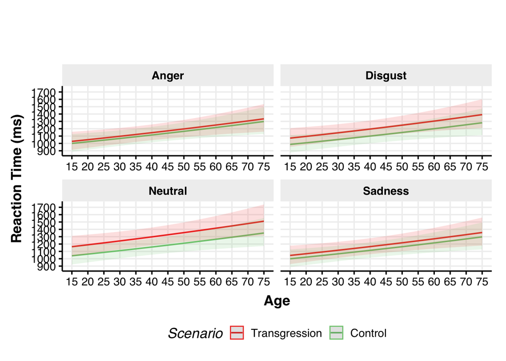

```r
plotfull2cov = ggpredict(full2cov, terms = c("age", "scenarios", "newemo"), ci_level = 0.95) %>%
  plot() +
  labs(x = "Age", y = "Reaction Time (ms)", colour = "Scenario", title = "", element_text(size = 14)) +
  scale_fill_Publication() +
  scale_colour_Publication() +
  theme_Publication() +
  scale_x_continuous(breaks = c(15, 20, 25, 30, 35, 40, 45, 50, 55, 60, 65, 70, 75)) +
  scale_y_continuous(breaks = c(800, 900, 1000, 1100, 1200, 1300, 1400, 1500, 1600, 1700))
plotfull2cov
```

#### Emotional Hits with Condition, Emotion and Class + covariates (preregistered)

Full mixed-effect model

```r
emo2cov = glmer(score ~  condition * newemo * scenarios + age + newgender + political_orientation + (1|number_ID) + (1|item),
          data = data2,
          family = binomial,
          na.action = na.omit,
          control = glmerControl(optimizer = "bobyqa"))
```

Summary

```r
tbl_regression(full2cov,
               label = list(condition ~ "Condition",
                            scenarios ~ "Scenarios",
                            newemo ~ "Emotion",
                            age ~ "Age",
                            newgender ~ "Sex",
                            political_orientation ~ "Political Orientation (1-Liberal to 7-Conservative)")) %>%
  modify_column_unhide(column = std.error) %>%
  modify_column_unhide(column = statistic) %>%
  modify_header(label = "**Variable**") %>%
  bold_p() %>%
  modify_fmt_fun(statistic ~ style_sigfig) %>%
  add_significance_stars(hide_ci = FALSE,
                         hide_p = FALSE,
                         pattern = "{p.value}{stars}") %>%
  add_glance_source_note(label = list(sigma ~ "\U03C3"),
                         include = c(AIC, sigma))
```

| **Variable** | **Beta** | **SE**<sup>1</sup> | **Statistic** | **95% CI**<sup>1</sup> | **p-value**<sup>2</sup> |
| --- | --- | --- | --- | --- | --- |
| Condition |  |  |  |  |  |
| Perpetrator | — | — | — | — |  |
| Victim | -0.05 | 0.044 | -1.2 | -0.14, 0.03 | 0.2 |
| Emotion |  |  |  |  |  |
| Anger | — | — | — | — |  |
| Disgust | 0.04 | 0.017 | 2.4 | 0.01, 0.08 | 0.016* |
| Neutral | 0.12 | 0.018 | 7.1 | 0.09, 0.16 | <0.001*** |
| Sadness | 0.02 | 0.017 | 0.95 | -0.02, 0.05 | 0.3 |
| Scenarios |  |  |  |  |  |
| Transgression | — | — | — | — |  |
| Control | -0.03 | 0.024 | -1.2 | -0.08, 0.02 | 0.3 |
| Age | 0.00 | 0.002 | 2.9 | 0.00, 0.01 | 0.005** |
| Sex |  |  |  |  |  |
| Female | — | — | — | — |  |
| Male | -0.02 | 0.042 | -0.55 | -0.11, 0.06 | 0.6 |
| Political Orientation (1-Liberal to 7-Conservative) |  |  |  |  |  |
| 1 | — | — | — | — |  |
| 2 | -0.06 | 0.060 | -0.92 | -0.18, 0.06 | 0.4 |
| 3 | 0.03 | 0.065 | 0.50 | -0.10, 0.16 | 0.6 |
| 4 | -0.09 | 0.067 | -1.4 | -0.22, 0.04 | 0.2 |
| 5 | -0.14 | 0.071 | -2.0 | -0.29, 0.00 | 0.046* |
| 6 | -0.08 | 0.084 | -1.0 | -0.25, 0.08 | 0.3 |
| 7 | -0.17 | 0.089 | -1.9 | -0.35, 0.00 | 0.056 |
| Condition * Emotion |  |  |  |  |  |
| Victim * Disgust | 0.00 | 0.025 | 0.00 | -0.05, 0.05 | >0.9 |
| Victim * Neutral | -0.03 | 0.025 | -1.0 | -0.08, 0.02 | 0.3 |
| Victim * Sadness | -0.06 | 0.025 | -2.5 | -0.11, -0.01 | 0.013* |
| Condition * Scenarios |  |  |  |  |  |
| Victim * Control | 0.01 | 0.026 | 0.56 | -0.04, 0.07 | 0.6 |
| Emotion * Scenarios |  |  |  |  |  |
| Disgust * Control | -0.06 | 0.026 | -2.2 | -0.11, 0.00 | 0.032* |
| Neutral * Control | -0.08 | 0.026 | -3.3 | -0.14, -0.03 | 0.001** |
| Sadness * Control | -0.02 | 0.026 | -0.67 | -0.07, 0.03 | 0.5 |
| Condition * Emotion * Scenarios |  |  |  |  |  |
| Victim * Disgust * Control | 0.02 | 0.037 | 0.55 | -0.05, 0.09 | 0.6 |
| Victim * Neutral * Control | 0.03 | 0.037 | 0.84 | -0.04, 0.10 | 0.4 |
| Victim * Sadness * Control | 0.07 | 0.037 | 2.0 | 0.00, 0.15 | 0.043* |

AIC = 8,963; σ = 0.348  
<sup>1</sup> SE = Standard Error, CI = Confidence Interval  
<sup>2</sup> *p<0.05; **p<0.01; ***p<0.001

Anova & conditional and marginal coefficient of determination

```r
Anova(emo2cov, type = 3, ddf = "Satterthwaite")
```

```
## Analysis of Deviance Table (Type III Wald chisquare tests)
##
## Response: score
##                              Chisq Df Pr(>Chisq)
## (Intercept)                26.9211  1  2.119e-07 ***
## condition                   2.7776  1    0.09559 .
## newemo                     28.5578  3  2.774e-06 ***
## scenarios                   2.2536  1    0.13330
## age                         2.7366  1    0.09807 .
## newgender                   0.0652  1    0.79846
## political_orientation       3.2875  6    0.77200
## condition:newemo           25.4939  3  1.217e-05 ***
## condition:scenarios         3.4075  1    0.06490 .
## newemo:scenarios           46.4483  3  4.554e-10 ***
## condition:newemo:scenarios  9.9419  3    0.01907 *
## ---
## Signif. codes:  0 '***' 0.001 '**' 0.01 '*' 0.05 '.' 0.1 ' ' 1
```

```r
round(r.squaredGLMM(emo2cov, method = "marginal"), 4)
```

```
##                R2m    R2c
## theoretical 0.0442 0.3466
## delta       0.0288 0.2259
```

- Main effect of *Emotion*
  $$\chi^2(3)
  = 28.558, p < .001$$
- Interaction between *Emotion* and *Condition*
  $$\chi^2(3) = 25.494, p < .001$$
- Interaction between *Emotion* and *Scenarios*
  $$\chi^2(3) = 46.448, p < .001$$
- Interaction between *Emotion*, *Condition* and *Scenarios*
  $$\chi^2(3) = 9.942, p =
  .019$$

Variance explained by the model:
$$R^2_m =
2.88\% \text{ (fixed)}$$
$$R^2_c =
22.59\% \text{ (fixed + random)}$$
Pairwise comparisons (estimated marginal means and pairwise comparisons)

```r
emmeans(emo2cov, pairwise ~ newemo, lmer.df = "asymp", type = "response", adjust = "bonferroni")
```

```
## $emmeans
##  newemo   prob     SE  df asymp.LCL asymp.UCL
##  Anger   0.872 0.0159 Inf     0.837     0.900
##  Disgust 0.859 0.0171 Inf     0.822     0.890
##  Neutral 0.793 0.0228 Inf     0.745     0.835
##  Sadness 0.860 0.0171 Inf     0.823     0.890
##
## Results are averaged over the levels of: condition, scenarios, newgender, political_orientation
## Confidence level used: 0.95
## Intervals are back-transformed from the logit scale
##
## $contrasts
##  contrast          odds.ratio     SE  df null z.ratio p.value
##  Anger / Disgust        1.115 0.0853 Inf    1   1.420  0.9344
##  Anger / Neutral        1.771 0.1288 Inf    1   7.855  <.0001
##  Anger / Sadness        1.106 0.0852 Inf    1   1.312  1.0000
##  Disgust / Neutral      1.588 0.1144 Inf    1   6.425  <.0001
##  Disgust / Sadness      0.992 0.0758 Inf    1  -0.099  1.0000
##  Neutral / Sadness      0.625 0.0453 Inf    1  -6.481  <.0001
##
## Results are averaged over the levels of: condition, scenarios, newgender, political_orientation
## P value adjustment: bonferroni method for 6 tests
## Tests are performed on the log odds ratio scale
```

```r
emmeans(emo2cov, pairwise ~ newemo|condition, lmer.df = "asymp", type = "response", adjust = "bonferroni")
```

```
## $emmeans
## condition = Perpetrator:
##  newemo   prob     SE  df asymp.LCL asymp.UCL
##  Anger   0.859 0.0225 Inf     0.809     0.897
##  Disgust 0.856 0.0229 Inf     0.805     0.895
##  Neutral 0.772 0.0319 Inf     0.704     0.829
##  Sadness 0.821 0.0271 Inf     0.761     0.868
##
## condition = Victim:
##  newemo   prob     SE  df asymp.LCL asymp.UCL
##  Anger   0.884 0.0190 Inf     0.841     0.916
##  Disgust 0.862 0.0218 Inf     0.814     0.900
##  Neutral 0.813 0.0274 Inf     0.753     0.861
##  Sadness 0.892 0.0179 Inf     0.852     0.922
##
## Results are averaged over the levels of: scenarios, newgender, political_orientation
## Confidence level used: 0.95
## Intervals are back-transformed from the logit scale
##
## $contrasts
## condition = Perpetrator:
##  contrast          odds.ratio     SE  df null z.ratio p.value
##  Anger / Disgust        1.020 0.1072 Inf    1   0.190  1.0000
##  Anger / Neutral        1.792 0.1764 Inf    1   5.928  <.0001
##  Anger / Sadness        1.327 0.1363 Inf    1   2.753  0.0355
##  Disgust / Neutral      1.757 0.1743 Inf    1   5.680  <.0001
##  Disgust / Sadness      1.301 0.1345 Inf    1   2.541  0.0664
##  Neutral / Sadness      0.740 0.0714 Inf    1  -3.118  0.0109
##
## condition = Victim:
##  contrast          odds.ratio     SE  df null z.ratio p.value
##  Anger / Disgust        1.218 0.1355 Inf    1   1.774  0.4565
##  Anger / Neutral        1.749 0.1873 Inf    1   5.224  <.0001
##  Anger / Sadness        0.923 0.1059 Inf    1  -0.703  1.0000
##  Disgust / Neutral      1.436 0.1500 Inf    1   3.467  0.0032
##  Disgust / Sadness      0.757 0.0852 Inf    1  -2.470  0.0810
##  Neutral / Sadness      0.527 0.0572 Inf    1  -5.901  <.0001
##
## Results are averaged over the levels of: scenarios, newgender, political_orientation
## P value adjustment: bonferroni method for 6 tests
## Tests are performed on the log odds ratio scale
```

```r
emmeans(emo2cov, pairwise ~ newemo|scenarios, lmer.df = "asymp", type = "response", adjust = "bonferroni")
```

```
## $emmeans
## scenarios = Transgression:
##  newemo   prob     SE  df asymp.LCL asymp.UCL
##  Anger   0.867 0.0183 Inf     0.827     0.899
##  Disgust 0.822 0.0228 Inf     0.773     0.863
##  Neutral 0.819 0.0231 Inf     0.770     0.860
##  Sadness 0.829 0.0223 Inf     0.781     0.869
##
## scenarios = Control:
##  newemo   prob     SE  df asymp.LCL asymp.UCL
##  Anger   0.876 0.0180 Inf     0.836     0.907
##  Disgust 0.890 0.0165 Inf     0.853     0.918
##  Neutral 0.765 0.0288 Inf     0.704     0.817
##  Sadness 0.886 0.0169 Inf     0.849     0.915
##
## Results are averaged over the levels of: condition, newgender, political_orientation
## Confidence level used: 0.95
## Intervals are back-transformed from the logit scale
##
## $contrasts
## scenarios = Transgression:
##  contrast          odds.ratio     SE  df null z.ratio p.value
##  Anger / Disgust        1.415 0.1403 Inf    1   3.500  0.0028
##  Anger / Neutral        1.443 0.1430 Inf    1   3.699  0.0013
##  Anger / Sadness        1.347 0.1364 Inf    1   2.938  0.0198
##  Disgust / Neutral      1.020 0.0966 Inf    1   0.206  1.0000
##  Disgust / Sadness      0.952 0.0924 Inf    1  -0.509  1.0000
##  Neutral / Sadness      0.933 0.0906 Inf    1  -0.711  1.0000
##
## scenarios = Control:
##  contrast          odds.ratio     SE  df null z.ratio p.value
##  Anger / Disgust        0.878 0.1024 Inf    1  -1.113  1.0000
##  Anger / Neutral        2.173 0.2308 Inf    1   7.307  <.0001
##  Anger / Sadness        0.909 0.1055 Inf    1  -0.823  1.0000
##  Disgust / Neutral      2.474 0.2684 Inf    1   8.352  <.0001
##  Disgust / Sadness      1.035 0.1221 Inf    1   0.291  1.0000
##  Neutral / Sadness      0.418 0.0451 Inf    1  -8.082  <.0001
##
## Results are averaged over the levels of: condition, newgender, political_orientation
## P value adjustment: bonferroni method for 6 tests
## Tests are performed on the log odds ratio scale
```

```r
emmeans(emo2cov, pairwise ~ condition*newemo*scenarios, lmer.df = "asymp", type = "response", adjust = "bonferroni")
```

```
## $emmeans
##  condition   newemo  scenarios      prob     SE  df asymp.LCL asymp.UCL
##  Perpetrator Anger   Transgression 0.841 0.0270 Inf     0.780     0.887
##  Victim      Anger   Transgression 0.890 0.0202 Inf     0.844     0.924
##  Perpetrator Disgust Transgression 0.801 0.0317 Inf     0.731     0.856
##  Victim      Disgust Transgression 0.841 0.0268 Inf     0.782     0.887
##  Perpetrator Neutral Transgression 0.786 0.0333 Inf     0.714     0.844
##  Victim      Neutral Transgression 0.848 0.0259 Inf     0.790     0.892
##  Perpetrator Sadness Transgression 0.730 0.0387 Inf     0.648     0.799
##  Victim      Sadness Transgression 0.897 0.0192 Inf     0.853     0.929
##  Perpetrator Anger   Control       0.875 0.0233 Inf     0.821     0.914
##  Victim      Anger   Control       0.878 0.0229 Inf     0.825     0.916
##  Perpetrator Disgust Control       0.898 0.0199 Inf     0.852     0.931
##  Victim      Disgust Control       0.881 0.0225 Inf     0.829     0.918
##  Perpetrator Neutral Control       0.757 0.0374 Inf     0.677     0.823
##  Victim      Neutral Control       0.773 0.0357 Inf     0.695     0.835
##  Perpetrator Sadness Control       0.886 0.0217 Inf     0.836     0.922
##  Victim      Sadness Control       0.886 0.0216 Inf     0.837     0.922
##
## Results are averaged over the levels of: newgender, political_orientation
## Confidence level used: 0.95
## Intervals are back-transformed from the logit scale
##
## $contrasts
##  contrast
##  Perpetrator Anger Transgression / Victim Anger Transgression
##  Perpetrator Anger Transgression / Perpetrator Disgust Transgression
##  Perpetrator Anger Transgression / Victim Disgust Transgression
##  Perpetrator Anger Transgression / Perpetrator Neutral Transgression
##  Perpetrator Anger Transgression / Victim Neutral Transgression
##  Perpetrator Anger Transgression / Perpetrator Sadness Transgression
##  Perpetrator Anger Transgression / Victim Sadness Transgression
##  Perpetrator Anger Transgression / Perpetrator Anger Control
##  Perpetrator Anger Transgression / Victim Anger Control
##  Perpetrator Anger Transgression / Perpetrator Disgust Control
##  Perpetrator Anger Transgression / Victim Disgust Control
##  Perpetrator Anger Transgression / Perpetrator Neutral Control
##  Perpetrator Anger Transgression / Victim Neutral Control
##  Perpetrator Anger Transgression / Perpetrator Sadness Control
##  Perpetrator Anger Transgression / Victim Sadness Control
```

[output cut: 215 more lines]

```
##       1.128 0.3053 Inf    1   0.443  1.0000
##       2.361 0.6125 Inf    1   3.311  0.1115
##       2.170 0.3343 Inf    1   5.030  0.0001
##       0.950 0.2547 Inf    1  -0.192  1.0000
##       0.944 0.1583 Inf    1  -0.345  1.0000
##       0.919 0.2307 Inf    1  -0.336  1.0000
##       0.402 0.0601 Inf    1  -6.094  <.0001
##       0.400 0.1040 Inf    1  -3.523  0.0512
##       0.438 0.1138 Inf    1  -3.177  0.1783
##       0.435 0.0676 Inf    1  -5.356  <.0001
##       0.994 0.2673 Inf    1  -0.024  1.0000
##
## Results are averaged over the levels of: newgender, political_orientation
## P value adjustment: bonferroni method for 120 tests
## Tests are performed on the log odds ratio scale
```

Plot all interaction effects

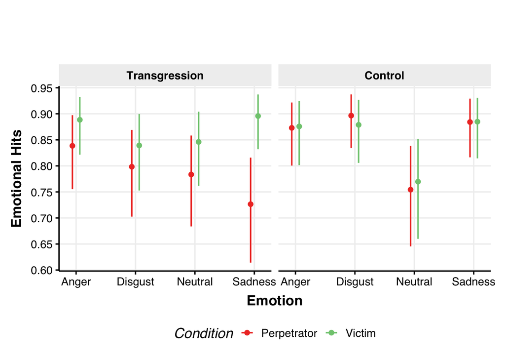

```r
plotemo2cov = ggpredict(emo2cov, terms = c("newemo", "condition", "scenarios"), ci_level = 0.95) %>%
  plot() +
  labs(x = "Emotion", y = "Emotional Hits", colour = "Condition", title = "", element_text(size = 14)) +
  scale_fill_Publication() +
  scale_colour_Publication() +
  theme_Publication() +
  scale_y_continuous(breaks = c(0.6, 0.65, 0.7, 0.75, 0.8, 0.85, 0.9, 0.95, 1))

plotemo2cov
```